# Expansión de la CASEN sobre el CENSO

De ingresos sobre una categoría de respuesta

VE-CC-AJ

DataIntelligence

Martes 22-06-2021

Abstract

Expandiremos los ingresos promedios comunales obtenidos de la CASEN sobre la categoría de respuesta: “tejas o tejuelas de arcilla, metálicas, de cemento, de madera, asfálticas o plásticas” del campo P03B del CENSO de viviendas, que fue la categoría de respuesta que más alto correlaciona con los ingresos expandidos, ambos a nivel comunal. Lo anterior, para poder construir un modelo lineal cuya variable independiente será: “porcentaje de población que posee la variable Censal respecto a la zona” y la dependiente: “ingreso expandido por zona”.

## 1 Variable CENSO

Necesitamos calcular las frecuencias a nivel censal de las respuestas correspondientes a la categoría: “tejas o tejuelas de arcilla, metálicas, de cemento, de madera, asfálticas o plásticas” del campo **P03B** del censo de viviendas. Recordemos que ésta fué la más alta correlación en relación a los ingresos expandidos [(ver punto 1.2 aquí)](https://rpubs.com/dataintelligence/corr_004_viviendas).

### 1.1 Lectura de la tabla de viviendas

```r
tabla_con_clave <- readRDS("censo_viviendas_con_clave_17.rds")

r3_100 <- tabla_con_clave[c(1:100),]

kbl(r3_100) %>%
  kable_styling(bootstrap_options = c("striped", "hover")) %>%
  kable_paper() %>%
  scroll_box(width = "100%", height = "300px")
```

| REGION | PROVINCIA | COMUNA | DC | AREA | ZC_LOC | ID_ZONA_LOC | NVIV | P01 | P02 | P03A | P03B | P03C | P04 | P05 | CANT_HOG | CANT_PER | REGION_15R | PROVINCIA_15R | COMUNA_15R | clave |
| --- | --- | --- | --- | --- | --- | --- | --- | --- | --- | --- | --- | --- | --- | --- | --- | --- | --- | --- | --- | --- |
| 15 | 152 | 15202 | 1 | 2 | 6 | 13225 | 1 | 3 | 1 | 5 | 3 | 5 | 1 | 4 | 1 | 1 | 15 | 152 | 15202 | 15202012006 |
| 15 | 152 | 15202 | 1 | 2 | 6 | 13225 | 2 | 1 | 3 | 98 | 98 | 98 | 98 | 98 | 0 | 0 | 15 | 152 | 15202 | 15202012006 |
| 15 | 152 | 15202 | 1 | 2 | 6 | 13225 | 3 | 1 | 1 | 5 | 3 | 5 | 2 | 3 | 1 | 4 | 15 | 152 | 15202 | 15202012006 |
| 15 | 152 | 15202 | 1 | 2 | 6 | 13225 | 4 | 1 | 4 | 98 | 98 | 98 | 98 | 98 | 0 | 0 | 15 | 152 | 15202 | 15202012006 |
| 15 | 152 | 15202 | 1 | 2 | 6 | 13225 | 5 | 3 | 4 | 98 | 98 | 98 | 98 | 98 | 0 | 0 | 15 | 152 | 15202 | 15202012006 |
| 15 | 152 | 15202 | 1 | 2 | 6 | 13225 | 6 | 3 | 4 | 98 | 98 | 98 | 98 | 98 | 0 | 0 | 15 | 152 | 15202 | 15202012006 |
| 15 | 152 | 15202 | 1 | 2 | 6 | 13225 | 7 | 3 | 4 | 98 | 98 | 98 | 98 | 98 | 0 | 0 | 15 | 152 | 15202 | 15202012006 |
| 15 | 152 | 15202 | 1 | 2 | 6 | 13225 | 8 | 3 | 3 | 98 | 98 | 98 | 98 | 98 | 0 | 0 | 15 | 152 | 15202 | 15202012006 |
| 15 | 152 | 15202 | 1 | 2 | 6 | 13225 | 9 | 3 | 1 | 5 | 3 | 5 | 1 | 4 | 1 | 4 | 15 | 152 | 15202 | 15202012006 |
| 15 | 152 | 15202 | 1 | 2 | 6 | 13225 | 10 | 1 | 1 | 5 | 3 | 4 | 1 | 4 | 1 | 1 | 15 | 152 | 15202 | 15202012006 |
| 15 | 152 | 15202 | 1 | 2 | 6 | 13225 | 11 | 1 | 2 | 98 | 98 | 98 | 98 | 98 | 0 | 0 | 15 | 152 | 15202 | 15202012006 |
| 15 | 152 | 15202 | 1 | 2 | 6 | 13225 | 12 | 1 | 4 | 98 | 98 | 98 | 98 | 98 | 0 | 0 | 15 | 152 | 15202 | 15202012006 |
| 15 | 152 | 15202 | 1 | 2 | 6 | 13225 | 13 | 1 | 1 | 5 | 3 | 4 | 1 | 4 | 1 | 3 | 15 | 152 | 15202 | 15202012006 |
| 15 | 152 | 15202 | 1 | 2 | 6 | 13225 | 14 | 1 | 3 | 98 | 98 | 98 | 98 | 98 | 0 | 0 | 15 | 152 | 15202 | 15202012006 |
| 15 | 152 | 15202 | 1 | 2 | 6 | 13225 | 15 | 1 | 4 | 98 | 98 | 98 | 98 | 98 | 0 | 0 | 15 | 152 | 15202 | 15202012006 |
| 15 | 152 | 15202 | 1 | 2 | 6 | 13225 | 16 | 1 | 1 | 5 | 3 | 5 | 1 | 3 | 1 | 3 | 15 | 152 | 15202 | 15202012006 |
| 15 | 152 | 15202 | 1 | 2 | 6 | 13225 | 17 | 1 | 1 | 5 | 3 | 5 | 2 | 4 | 1 | 8 | 15 | 152 | 15202 | 15202012006 |
| 15 | 152 | 15202 | 1 | 2 | 6 | 13225 | 18 | 3 | 1 | 5 | 3 | 5 | 1 | 1 | 1 | 1 | 15 | 152 | 15202 | 15202012006 |
| 15 | 152 | 15202 | 1 | 2 | 6 | 13225 | 19 | 3 | 1 | 5 | 3 | 5 | 1 | 3 | 1 | 1 | 15 | 152 | 15202 | 15202012006 |
| 15 | 152 | 15202 | 1 | 2 | 6 | 13225 | 20 | 1 | 1 | 5 | 3 | 5 | 2 | 1 | 1 | 2 | 15 | 152 | 15202 | 15202012006 |
| 15 | 152 | 15202 | 1 | 2 | 6 | 13225 | 21 | 1 | 4 | 98 | 98 | 98 | 98 | 98 | 0 | 0 | 15 | 152 | 15202 | 15202012006 |
| 15 | 152 | 15202 | 1 | 2 | 6 | 13225 | 22 | 1 | 4 | 98 | 98 | 98 | 98 | 98 | 0 | 0 | 15 | 152 | 15202 | 15202012006 |
| 15 | 152 | 15202 | 1 | 2 | 6 | 13225 | 23 | 3 | 4 | 98 | 98 | 98 | 98 | 98 | 0 | 0 | 15 | 152 | 15202 | 15202012006 |
| 15 | 152 | 15202 | 1 | 2 | 6 | 13225 | 24 | 1 | 3 | 98 | 98 | 98 | 98 | 98 | 0 | 0 | 15 | 152 | 15202 | 15202012006 |
| 15 | 152 | 15202 | 1 | 2 | 6 | 13225 | 25 | 1 | 1 | 5 | 3 | 5 | 1 | 4 | 1 | 2 | 15 | 152 | 15202 | 15202012006 |
| 15 | 152 | 15202 | 1 | 2 | 6 | 13225 | 26 | 1 | 4 | 98 | 98 | 98 | 98 | 98 | 0 | 0 | 15 | 152 | 15202 | 15202012006 |
| 15 | 152 | 15202 | 1 | 2 | 6 | 13225 | 27 | 3 | 4 | 98 | 98 | 98 | 98 | 98 | 0 | 0 | 15 | 152 | 15202 | 15202012006 |
| 15 | 152 | 15202 | 1 | 2 | 6 | 13225 | 28 | 3 | 1 | 5 | 3 | 5 | 1 | 4 | 1 | 5 | 15 | 152 | 15202 | 15202012006 |
| 15 | 152 | 15202 | 1 | 2 | 6 | 13225 | 29 | 1 | 4 | 98 | 98 | 98 | 98 | 98 | 0 | 0 | 15 | 152 | 15202 | 15202012006 |
| 15 | 152 | 15202 | 1 | 2 | 6 | 13225 | 30 | 3 | 4 | 98 | 98 | 98 | 98 | 98 | 0 | 0 | 15 | 152 | 15202 | 15202012006 |

[output cut: 70 more lines]

### 1.2 Cálculo de frecuencias

Necesitamos obtener por zona la cantidad de personas que declaran tener como material en la cubierta del techo: “tejas o tejuelas de arcilla, metálicas, de cemento, de madera, asfálticas o plásticas” (la mayor correlación obtenida en relación al ingreso promedio comunal obtenido de la CASEN).

```r
tabla_con_clave_f <- tabla_con_clave[,-c(1,2,4,5,6,7,8,9,10,11,13,14,15,16,17,18,19,20),drop=FALSE]
names(tabla_con_clave_f)[2] <- "Tipo de techo"
# Ahora filtramos por Tipo de techo = 1.
tabla_con_clave_ff <- filter(tabla_con_clave_f, tabla_con_clave_f$`Tipo de techo` == 1)
# Determinamos las frecuencias por zona:
b <- tabla_con_clave_ff$clave
c <- tabla_con_clave_ff$`Tipo de techo`
d <- tabla_con_clave_ff$COMUNA
cross_tab =  xtabs( ~ unlist(b) + unlist(c)+ unlist(d))
tabla <- as.data.frame(cross_tab)
d <-tabla[!(tabla$Freq == 0),]
names(d)[1] <- "zona"
d$anio <- "2017"
```

### 1.3 Veamos los primeros 100 registros

```r
r3_100 <- d[c(1:100),]
kbl(r3_100) %>%
  kable_styling(bootstrap_options = c("striped", "hover")) %>%
  kable_paper() %>%
  scroll_box(width = "100%", height = "300px")
```

|  | zona | unlist.c. | unlist.d. | Freq | anio |
| --- | --- | --- | --- | --- | --- |
| 1161 | 1101011001 | 1 | 1101 | 298 | 2017 |
| 1162 | 1101011002 | 1 | 1101 | 95 | 2017 |
| 1163 | 1101021001 | 1 | 1101 | 55 | 2017 |
| 1164 | 1101021002 | 1 | 1101 | 2 | 2017 |
| 1165 | 1101021003 | 1 | 1101 | 265 | 2017 |
| 1166 | 1101021004 | 1 | 1101 | 178 | 2017 |
| 1167 | 1101021005 | 1 | 1101 | 337 | 2017 |
| 1168 | 1101031001 | 1 | 1101 | 194 | 2017 |
| 1169 | 1101031002 | 1 | 1101 | 482 | 2017 |
| 1170 | 1101031003 | 1 | 1101 | 328 | 2017 |
| 1171 | 1101031004 | 1 | 1101 | 171 | 2017 |
| 1172 | 1101041001 | 1 | 1101 | 135 | 2017 |
| 1173 | 1101041002 | 1 | 1101 | 228 | 2017 |
| 1174 | 1101041003 | 1 | 1101 | 235 | 2017 |
| 1175 | 1101041004 | 1 | 1101 | 636 | 2017 |
| 1176 | 1101041005 | 1 | 1101 | 403 | 2017 |
| 1177 | 1101041006 | 1 | 1101 | 214 | 2017 |
| 1178 | 1101051001 | 1 | 1101 | 364 | 2017 |
| 1179 | 1101051002 | 1 | 1101 | 350 | 2017 |
| 1180 | 1101051003 | 1 | 1101 | 303 | 2017 |
| 1181 | 1101051004 | 1 | 1101 | 200 | 2017 |
| 1182 | 1101051005 | 1 | 1101 | 269 | 2017 |
| 1183 | 1101051006 | 1 | 1101 | 256 | 2017 |
| 1184 | 1101061001 | 1 | 1101 | 105 | 2017 |
| 1185 | 1101061002 | 1 | 1101 | 349 | 2017 |
| 1186 | 1101061003 | 1 | 1101 | 259 | 2017 |
| 1187 | 1101061004 | 1 | 1101 | 134 | 2017 |
| 1188 | 1101061005 | 1 | 1101 | 144 | 2017 |
| 1189 | 1101071001 | 1 | 1101 | 271 | 2017 |
| 1190 | 1101071002 | 1 | 1101 | 453 | 2017 |

[output cut: 70 more lines]

### 1.4 Calculamos la proporción de las frecuencias en cada comuna a nivel zonal (**p**)

```r
codigos_com <- unique(d$unlist.d.)
frec_man_com_parcial_total <- data.frame()
for(i in codigos_com){
  # debemos dividir por 100 para obtener las proporciones y no los porcentajes:
  frec_man_com_parcial <- filter(d, d$unlist.d. == i)
  frec_man_com_parcial$p <- frec_man_com_parcial$Freq*100/sum(frec_man_com_parcial$Freq)/100
  frec_man_com_parcial_total <- rbind(frec_man_com_parcial_total,frec_man_com_parcial)
}
```

### 1.5 Observemos los primeros 100 registros

```r
r3_100 <- frec_man_com_parcial_total[c(1:100),]

kbl(r3_100) %>%
  kable_styling(bootstrap_options = c("striped", "hover")) %>%
  kable_paper() %>%
  scroll_box(width = "100%", height = "300px")
```

| zona | unlist.c. | unlist.d. | Freq | anio | p |
| --- | --- | --- | --- | --- | --- |
| 1101011001 | 1 | 1101 | 298 | 2017 | 0.0192035 |
| 1101011002 | 1 | 1101 | 95 | 2017 | 0.0061219 |
| 1101021001 | 1 | 1101 | 55 | 2017 | 0.0035443 |
| 1101021002 | 1 | 1101 | 2 | 2017 | 0.0001289 |
| 1101021003 | 1 | 1101 | 265 | 2017 | 0.0170769 |
| 1101021004 | 1 | 1101 | 178 | 2017 | 0.0114706 |
| 1101021005 | 1 | 1101 | 337 | 2017 | 0.0217167 |
| 1101031001 | 1 | 1101 | 194 | 2017 | 0.0125016 |
| 1101031002 | 1 | 1101 | 482 | 2017 | 0.0310607 |
| 1101031003 | 1 | 1101 | 328 | 2017 | 0.0211367 |
| 1101031004 | 1 | 1101 | 171 | 2017 | 0.0110195 |
| 1101041001 | 1 | 1101 | 135 | 2017 | 0.0086996 |
| 1101041002 | 1 | 1101 | 228 | 2017 | 0.0146926 |
| 1101041003 | 1 | 1101 | 235 | 2017 | 0.0151437 |
| 1101041004 | 1 | 1101 | 636 | 2017 | 0.0409847 |
| 1101041005 | 1 | 1101 | 403 | 2017 | 0.0259698 |
| 1101041006 | 1 | 1101 | 214 | 2017 | 0.0137904 |
| 1101051001 | 1 | 1101 | 364 | 2017 | 0.0234566 |
| 1101051002 | 1 | 1101 | 350 | 2017 | 0.0225545 |
| 1101051003 | 1 | 1101 | 303 | 2017 | 0.0195257 |
| 1101051004 | 1 | 1101 | 200 | 2017 | 0.0128883 |
| 1101051005 | 1 | 1101 | 269 | 2017 | 0.0173347 |
| 1101051006 | 1 | 1101 | 256 | 2017 | 0.0164970 |
| 1101061001 | 1 | 1101 | 105 | 2017 | 0.0067663 |
| 1101061002 | 1 | 1101 | 349 | 2017 | 0.0224900 |
| 1101061003 | 1 | 1101 | 259 | 2017 | 0.0166903 |
| 1101061004 | 1 | 1101 | 134 | 2017 | 0.0086351 |
| 1101061005 | 1 | 1101 | 144 | 2017 | 0.0092795 |
| 1101071001 | 1 | 1101 | 271 | 2017 | 0.0174636 |
| 1101071002 | 1 | 1101 | 453 | 2017 | 0.0291919 |

[output cut: 70 more lines]

### 1.6 Verificación del cálculo correcto de proporciones

Verifiquemos que la suma de las proporciones sea 1 para la comuna 1107:

```r
r3_100_f <- filter(frec_man_com_parcial_total, frec_man_com_parcial_total$unlist.d. == 1107)
```

```r
sum(r3_100_f$p)
```

```
## [1] 1
```

```r
nrow(frec_man_com_parcial_total)
```

```
## [1] 12671
```

### 1.7 Agregamos un cero a los códigos comunales de cuatro digitos

```r
codigos <- frec_man_com_parcial_total$unlist.d.
rango <- seq(1:nrow(frec_man_com_parcial_total))
cadena <- paste("0",codigos[rango], sep = "")
cadena <- substr(cadena,(nchar(cadena)[rango])-(4),6)
codigos <- as.data.frame(codigos)
cadena <- as.data.frame(cadena)
comuna_corr <- cbind(frec_man_com_parcial_total,cadena)
comuna_corr <- comuna_corr[,-c(2,3),drop=FALSE]
names(comuna_corr)[5] <- "código"

r3_100 <- comuna_corr[c(1:100),]
kbl(r3_100) %>%
  kable_styling(bootstrap_options = c("striped", "hover")) %>%
  kable_paper() %>%
  scroll_box(width = "100%", height = "300px")
```

| zona | Freq | anio | p | código |
| --- | --- | --- | --- | --- |
| 1101011001 | 298 | 2017 | 0.0192035 | 01101 |
| 1101011002 | 95 | 2017 | 0.0061219 | 01101 |
| 1101021001 | 55 | 2017 | 0.0035443 | 01101 |
| 1101021002 | 2 | 2017 | 0.0001289 | 01101 |
| 1101021003 | 265 | 2017 | 0.0170769 | 01101 |
| 1101021004 | 178 | 2017 | 0.0114706 | 01101 |
| 1101021005 | 337 | 2017 | 0.0217167 | 01101 |
| 1101031001 | 194 | 2017 | 0.0125016 | 01101 |
| 1101031002 | 482 | 2017 | 0.0310607 | 01101 |
| 1101031003 | 328 | 2017 | 0.0211367 | 01101 |
| 1101031004 | 171 | 2017 | 0.0110195 | 01101 |
| 1101041001 | 135 | 2017 | 0.0086996 | 01101 |
| 1101041002 | 228 | 2017 | 0.0146926 | 01101 |
| 1101041003 | 235 | 2017 | 0.0151437 | 01101 |
| 1101041004 | 636 | 2017 | 0.0409847 | 01101 |
| 1101041005 | 403 | 2017 | 0.0259698 | 01101 |
| 1101041006 | 214 | 2017 | 0.0137904 | 01101 |
| 1101051001 | 364 | 2017 | 0.0234566 | 01101 |
| 1101051002 | 350 | 2017 | 0.0225545 | 01101 |
| 1101051003 | 303 | 2017 | 0.0195257 | 01101 |
| 1101051004 | 200 | 2017 | 0.0128883 | 01101 |
| 1101051005 | 269 | 2017 | 0.0173347 | 01101 |
| 1101051006 | 256 | 2017 | 0.0164970 | 01101 |
| 1101061001 | 105 | 2017 | 0.0067663 | 01101 |
| 1101061002 | 349 | 2017 | 0.0224900 | 01101 |
| 1101061003 | 259 | 2017 | 0.0166903 | 01101 |
| 1101061004 | 134 | 2017 | 0.0086351 | 01101 |
| 1101061005 | 144 | 2017 | 0.0092795 | 01101 |
| 1101071001 | 271 | 2017 | 0.0174636 | 01101 |
| 1101071002 | 453 | 2017 | 0.0291919 | 01101 |

[output cut: 70 more lines]

## 2 Variable CASEN

### 2.1 Tabla de ingresos expandidos

Hemos calculado ya éste valor en el resultado del punto 1.1 de [(aquí)](https://rpubs.com/dataintelligence/corr_casen_censo_002)

```r
h_y_m_2017_censo <- readRDS("ingresos_expandidos_17.rds")

tablamadre <- head(h_y_m_2017_censo,50)
kbl(tablamadre) %>%
  kable_styling(bootstrap_options = c("striped", "hover")) %>%
  kable_paper() %>%
  scroll_box(width = "100%", height = "300px")
```

| código | comuna.x | promedio_i | año | comuna.y | personas | Ingresos_expandidos |
| --- | --- | --- | --- | --- | --- | --- |
| 01101 | Iquique | 354820.7 | 2017 | 1101 | 191468 | 67936815240 |
| 01107 | Alto Hospicio | 301933.4 | 2017 | 1107 | 108375 | 32722034397 |
| 01401 | Pozo Almonte | 285981.8 | 2017 | 1401 | 15711 | 4493059532 |
| 01402 | Camiña | 262850.3 | 2017 | 1402 | 1250 | 328562901 |
| 01404 | Huara | 253968.5 | 2017 | 1404 | 2730 | 693334131 |
| 01405 | Pica | 313007.5 | 2017 | 1405 | 9296 | 2909717399 |
| 02101 | Antofagasta | 347580.2 | 2017 | 2101 | 361873 | 125779893517 |
| 02102 | Mejillones | 369770.7 | 2017 | 2102 | 13467 | 4979702302 |
| 02103 | Sierra Gorda | 403458.5 | 2017 | 2103 | 10186 | 4109628188 |
| 02104 | Taltal | 364539.1 | 2017 | 2104 | 13317 | 4854566842 |
| 02201 | Calama | 409671.3 | 2017 | 2201 | 165731 | 67895226712 |
| 02203 | San Pedro de Atacama | 426592.0 | 2017 | 2203 | 10996 | 4690805471 |
| 02301 | Tocopilla | 246615.3 | 2017 | 2301 | 25186 | 6211253937 |
| 02302 | María Elena | 466266.9 | 2017 | 2302 | 6457 | 3010685220 |
| 03101 | Copiapó | 330075.2 | 2017 | 3101 | 153937 | 50810778473 |
| 03102 | Caldera | 299314.8 | 2017 | 3102 | 17662 | 5286498241 |
| 03103 | Tierra Amarilla | 314643.9 | 2017 | 3103 | 14019 | 4410992711 |
| 03201 | Chañaral | 286389.3 | 2017 | 3201 | 12219 | 3499391196 |
| 03202 | Diego de Almagro | 336256.8 | 2017 | 3202 | 13925 | 4682376047 |
| 03301 | Vallenar | 304336.7 | 2017 | 3301 | 51917 | 15800246795 |
| 03302 | Alto del Carmen | 227130.4 | 2017 | 3302 | 5299 | 1203563833 |
| 03303 | Freirina | 253086.7 | 2017 | 3303 | 7041 | 1781983257 |
| 03304 | Huasco | 287406.6 | 2017 | 3304 | 10149 | 2916889629 |
| 04101 | La Serena | 270221.9 | 2017 | 4101 | 221054 | 59733627577 |
| 04102 | Coquimbo | 261852.6 | 2017 | 4102 | 227730 | 59631700074 |
| 04103 | Andacollo | 248209.3 | 2017 | 4103 | 11044 | 2741223967 |
| 04104 | La Higuera | 228356.8 | 2017 | 4104 | 4241 | 968461330 |
| 04105 | Paiguano | 205942.1 | 2017 | 4105 | 4497 | 926121774 |
| 04106 | Vicuña | 211431.9 | 2017 | 4106 | 27771 | 5871675449 |
| 04201 | Illapel | 238674.4 | 2017 | 4201 | 30848 | 7362627007 |
| 04202 | Canela | 207933.6 | 2017 | 4202 | 9093 | 1890740321 |
| 04203 | Los Vilos | 255200.4 | 2017 | 4203 | 21382 | 5456695139 |
| 04204 | Salamanca | 242879.5 | 2017 | 4204 | 29347 | 7127783272 |
| 04301 | Ovalle | 266522.9 | 2017 | 4301 | 111272 | 29656533187 |
| 04302 | Combarbalá | 210409.7 | 2017 | 4302 | 13322 | 2803077721 |
| 04303 | Monte Patria | 211907.9 | 2017 | 4303 | 30751 | 6516380780 |
| 04304 | Punitaqui | 194997.8 | 2017 | 4304 | 10956 | 2136395349 |
| 04305 | Río Hurtado | 182027.2 | 2017 | 4305 | 4278 | 778712384 |
| 05101 | Valparaíso | 298720.7 | 2017 | 5101 | 296655 | 88616992249 |
| 05102 | Casablanca | 312802.7 | 2017 | 5102 | 26867 | 8404070481 |
| 05103 | Concón | 318496.3 | 2017 | 5103 | 42152 | 13425257057 |
| 05105 | Puchuncaví | 288737.2 | 2017 | 5105 | 18546 | 5354920887 |
| 05107 | Quintero | 316659.1 | 2017 | 5107 | 31923 | 10108709691 |
| 05109 | Viña del Mar | 337006.1 | 2017 | 5109 | 334248 | 112643604611 |
| 05301 | Los Andes | 338182.5 | 2017 | 5301 | 66708 | 22559476922 |
| 05302 | Calle Larga | 245165.4 | 2017 | 5302 | 14832 | 3636293159 |
| 05303 | Rinconada | 281633.2 | 2017 | 5303 | 10207 | 2874630315 |
| 05304 | San Esteban | 220958.4 | 2017 | 5304 | 18855 | 4166170587 |
| 05401 | La Ligua | 229623.7 | 2017 | 5401 | 35390 | 8126381563 |
| 05402 | Cabildo | 249717.7 | 2017 | 5402 | 19388 | 4841527150 |

## 3 Unión

Hacemos la unión por el campo código de la tabla precedente con la de proporciones de la variable Censal por zona para unirlas con los ingresos expandidos. Obtenemos así información a nivel zonal.

```r
comunas_con_ing_exp = merge( x = comuna_corr, y = h_y_m_2017_censo, by = "código", all.x = TRUE)

r3_100 <- comunas_con_ing_exp[c(1:100),]

kbl(r3_100) %>%
  kable_styling(bootstrap_options = c("striped", "hover")) %>%
  kable_paper() %>%
  scroll_box(width = "100%", height = "300px")
```

| código | zona | Freq | anio | p | comuna.x | promedio_i | año | comuna.y | personas | Ingresos_expandidos |
| --- | --- | --- | --- | --- | --- | --- | --- | --- | --- | --- |
| 01101 | 1101111004 | 279 | 2017 | 0.0179791 | Iquique | 354820.7 | 2017 | 1101 | 191468 | 67936815240 |
| 01101 | 1101111005 | 359 | 2017 | 0.0231344 | Iquique | 354820.7 | 2017 | 1101 | 191468 | 67936815240 |
| 01101 | 1101051001 | 364 | 2017 | 0.0234566 | Iquique | 354820.7 | 2017 | 1101 | 191468 | 67936815240 |
| 01101 | 1101111006 | 60 | 2017 | 0.0038665 | Iquique | 354820.7 | 2017 | 1101 | 191468 | 67936815240 |
| 01101 | 1101111003 | 353 | 2017 | 0.0227478 | Iquique | 354820.7 | 2017 | 1101 | 191468 | 67936815240 |
| 01101 | 1101092016 | 1 | 2017 | 0.0000644 | Iquique | 354820.7 | 2017 | 1101 | 191468 | 67936815240 |
| 01101 | 1101092017 | 5 | 2017 | 0.0003222 | Iquique | 354820.7 | 2017 | 1101 | 191468 | 67936815240 |
| 01101 | 1101051002 | 350 | 2017 | 0.0225545 | Iquique | 354820.7 | 2017 | 1101 | 191468 | 67936815240 |
| 01101 | 1101111007 | 234 | 2017 | 0.0150793 | Iquique | 354820.7 | 2017 | 1101 | 191468 | 67936815240 |
| 01101 | 1101092021 | 11 | 2017 | 0.0007089 | Iquique | 354820.7 | 2017 | 1101 | 191468 | 67936815240 |
| 01101 | 1101111008 | 322 | 2017 | 0.0207501 | Iquique | 354820.7 | 2017 | 1101 | 191468 | 67936815240 |
| 01101 | 1101041005 | 403 | 2017 | 0.0259698 | Iquique | 354820.7 | 2017 | 1101 | 191468 | 67936815240 |
| 01101 | 1101092019 | 2 | 2017 | 0.0001289 | Iquique | 354820.7 | 2017 | 1101 | 191468 | 67936815240 |
| 01101 | 1101112901 | 1 | 2017 | 0.0000644 | Iquique | 354820.7 | 2017 | 1101 | 191468 | 67936815240 |
| 01101 | 1101111002 | 184 | 2017 | 0.0118572 | Iquique | 354820.7 | 2017 | 1101 | 191468 | 67936815240 |
| 01101 | 1101051004 | 200 | 2017 | 0.0128883 | Iquique | 354820.7 | 2017 | 1101 | 191468 | 67936815240 |
| 01101 | 1101092018 | 6 | 2017 | 0.0003866 | Iquique | 354820.7 | 2017 | 1101 | 191468 | 67936815240 |
| 01101 | 1101041006 | 214 | 2017 | 0.0137904 | Iquique | 354820.7 | 2017 | 1101 | 191468 | 67936815240 |
| 01101 | 1101051003 | 303 | 2017 | 0.0195257 | Iquique | 354820.7 | 2017 | 1101 | 191468 | 67936815240 |
| 01101 | 1101112003 | 9 | 2017 | 0.0005800 | Iquique | 354820.7 | 2017 | 1101 | 191468 | 67936815240 |
| 01101 | 1101112013 | 9 | 2017 | 0.0005800 | Iquique | 354820.7 | 2017 | 1101 | 191468 | 67936815240 |
| 01101 | 1101051005 | 269 | 2017 | 0.0173347 | Iquique | 354820.7 | 2017 | 1101 | 191468 | 67936815240 |
| 01101 | 1101021002 | 2 | 2017 | 0.0001289 | Iquique | 354820.7 | 2017 | 1101 | 191468 | 67936815240 |
| 01101 | 1101991999 | 68 | 2017 | 0.0043820 | Iquique | 354820.7 | 2017 | 1101 | 191468 | 67936815240 |
| 01101 | 1101081002 | 469 | 2017 | 0.0302230 | Iquique | 354820.7 | 2017 | 1101 | 191468 | 67936815240 |
| 01101 | 1101101005 | 481 | 2017 | 0.0309963 | Iquique | 354820.7 | 2017 | 1101 | 191468 | 67936815240 |
| 01101 | 1101111014 | 138 | 2017 | 0.0088929 | Iquique | 354820.7 | 2017 | 1101 | 191468 | 67936815240 |
| 01101 | 1101011002 | 95 | 2017 | 0.0061219 | Iquique | 354820.7 | 2017 | 1101 | 191468 | 67936815240 |
| 01101 | 1101011001 | 298 | 2017 | 0.0192035 | Iquique | 354820.7 | 2017 | 1101 | 191468 | 67936815240 |
| 01101 | 1101092012 | 3 | 2017 | 0.0001933 | Iquique | 354820.7 | 2017 | 1101 | 191468 | 67936815240 |

[output cut: 70 more lines]

## 4 Pasos según Notion

### 4.1 Del censo obtener la cantidad de población a nivel de zona y estimar la proporción (p_poblacional).

Ya hemos construído una tabla en la que tenemos la proporción de población por zona en cada comuna [(ver aquí)](https://rpubs.com/dataintelligence/tabla_de_proporciones).

```r
prop_pob <- readRDS("tabla_de_prop_pob.rds")
names(prop_pob)[1] <- "zona"
names(prop_pob)[3] <- "p_poblacional"
nrow(prop_pob)
```

```
## [1] 15500
```

Veamos los 100 primeros registros.

```r
r3_100 <- prop_pob[c(1:100),]
kbl(r3_100) %>%
  kable_styling(bootstrap_options = c("striped", "hover")) %>%
  kable_paper() %>%
  scroll_box(width = "100%", height = "300px")
```

| zona | Freq | p_poblacional | código |
| --- | --- | --- | --- |
| 1101011001 | 2491 | 0.0130100 | 01101 |
| 1101011002 | 1475 | 0.0077036 | 01101 |
| 1101021001 | 1003 | 0.0052385 | 01101 |
| 1101021002 | 54 | 0.0002820 | 01101 |
| 1101021003 | 2895 | 0.0151200 | 01101 |
| 1101021004 | 2398 | 0.0125243 | 01101 |
| 1101021005 | 4525 | 0.0236332 | 01101 |
| 1101031001 | 2725 | 0.0142321 | 01101 |
| 1101031002 | 3554 | 0.0185618 | 01101 |
| 1101031003 | 5246 | 0.0273988 | 01101 |
| 1101031004 | 3389 | 0.0177001 | 01101 |
| 1101041001 | 1800 | 0.0094010 | 01101 |
| 1101041002 | 2538 | 0.0132555 | 01101 |
| 1101041003 | 3855 | 0.0201339 | 01101 |
| 1101041004 | 5663 | 0.0295767 | 01101 |
| 1101041005 | 4162 | 0.0217373 | 01101 |
| 1101041006 | 2689 | 0.0140441 | 01101 |
| 1101051001 | 3296 | 0.0172144 | 01101 |
| 1101051002 | 4465 | 0.0233198 | 01101 |
| 1101051003 | 4656 | 0.0243174 | 01101 |
| 1101051004 | 2097 | 0.0109522 | 01101 |
| 1101051005 | 3569 | 0.0186402 | 01101 |
| 1101051006 | 2741 | 0.0143157 | 01101 |
| 1101061001 | 1625 | 0.0084871 | 01101 |
| 1101061002 | 4767 | 0.0248971 | 01101 |
| 1101061003 | 4826 | 0.0252053 | 01101 |
| 1101061004 | 4077 | 0.0212934 | 01101 |
| 1101061005 | 2166 | 0.0113126 | 01101 |
| 1101071001 | 2324 | 0.0121378 | 01101 |
| 1101071002 | 2801 | 0.0146291 | 01101 |

[output cut: 70 more lines]

### 4.2 Obtener el ingreso medio.

Éste valor es el campo promedio_i de la tabla calculada en el punto “3 Unión” de la sección anterior.

```r
r3_100 <- comunas_con_ing_exp[c(1:100),]
kbl(r3_100) %>%
  kable_styling(bootstrap_options = c("striped", "hover")) %>%
  kable_paper() %>%
  scroll_box(width = "100%", height = "300px")
```

| código | zona | Freq | anio | p | comuna.x | promedio_i | año | comuna.y | personas | Ingresos_expandidos |
| --- | --- | --- | --- | --- | --- | --- | --- | --- | --- | --- |
| 01101 | 1101111004 | 279 | 2017 | 0.0179791 | Iquique | 354820.7 | 2017 | 1101 | 191468 | 67936815240 |
| 01101 | 1101111005 | 359 | 2017 | 0.0231344 | Iquique | 354820.7 | 2017 | 1101 | 191468 | 67936815240 |
| 01101 | 1101051001 | 364 | 2017 | 0.0234566 | Iquique | 354820.7 | 2017 | 1101 | 191468 | 67936815240 |
| 01101 | 1101111006 | 60 | 2017 | 0.0038665 | Iquique | 354820.7 | 2017 | 1101 | 191468 | 67936815240 |
| 01101 | 1101111003 | 353 | 2017 | 0.0227478 | Iquique | 354820.7 | 2017 | 1101 | 191468 | 67936815240 |
| 01101 | 1101092016 | 1 | 2017 | 0.0000644 | Iquique | 354820.7 | 2017 | 1101 | 191468 | 67936815240 |
| 01101 | 1101092017 | 5 | 2017 | 0.0003222 | Iquique | 354820.7 | 2017 | 1101 | 191468 | 67936815240 |
| 01101 | 1101051002 | 350 | 2017 | 0.0225545 | Iquique | 354820.7 | 2017 | 1101 | 191468 | 67936815240 |
| 01101 | 1101111007 | 234 | 2017 | 0.0150793 | Iquique | 354820.7 | 2017 | 1101 | 191468 | 67936815240 |
| 01101 | 1101092021 | 11 | 2017 | 0.0007089 | Iquique | 354820.7 | 2017 | 1101 | 191468 | 67936815240 |
| 01101 | 1101111008 | 322 | 2017 | 0.0207501 | Iquique | 354820.7 | 2017 | 1101 | 191468 | 67936815240 |
| 01101 | 1101041005 | 403 | 2017 | 0.0259698 | Iquique | 354820.7 | 2017 | 1101 | 191468 | 67936815240 |
| 01101 | 1101092019 | 2 | 2017 | 0.0001289 | Iquique | 354820.7 | 2017 | 1101 | 191468 | 67936815240 |
| 01101 | 1101112901 | 1 | 2017 | 0.0000644 | Iquique | 354820.7 | 2017 | 1101 | 191468 | 67936815240 |
| 01101 | 1101111002 | 184 | 2017 | 0.0118572 | Iquique | 354820.7 | 2017 | 1101 | 191468 | 67936815240 |
| 01101 | 1101051004 | 200 | 2017 | 0.0128883 | Iquique | 354820.7 | 2017 | 1101 | 191468 | 67936815240 |
| 01101 | 1101092018 | 6 | 2017 | 0.0003866 | Iquique | 354820.7 | 2017 | 1101 | 191468 | 67936815240 |
| 01101 | 1101041006 | 214 | 2017 | 0.0137904 | Iquique | 354820.7 | 2017 | 1101 | 191468 | 67936815240 |
| 01101 | 1101051003 | 303 | 2017 | 0.0195257 | Iquique | 354820.7 | 2017 | 1101 | 191468 | 67936815240 |
| 01101 | 1101112003 | 9 | 2017 | 0.0005800 | Iquique | 354820.7 | 2017 | 1101 | 191468 | 67936815240 |
| 01101 | 1101112013 | 9 | 2017 | 0.0005800 | Iquique | 354820.7 | 2017 | 1101 | 191468 | 67936815240 |
| 01101 | 1101051005 | 269 | 2017 | 0.0173347 | Iquique | 354820.7 | 2017 | 1101 | 191468 | 67936815240 |
| 01101 | 1101021002 | 2 | 2017 | 0.0001289 | Iquique | 354820.7 | 2017 | 1101 | 191468 | 67936815240 |
| 01101 | 1101991999 | 68 | 2017 | 0.0043820 | Iquique | 354820.7 | 2017 | 1101 | 191468 | 67936815240 |
| 01101 | 1101081002 | 469 | 2017 | 0.0302230 | Iquique | 354820.7 | 2017 | 1101 | 191468 | 67936815240 |
| 01101 | 1101101005 | 481 | 2017 | 0.0309963 | Iquique | 354820.7 | 2017 | 1101 | 191468 | 67936815240 |
| 01101 | 1101111014 | 138 | 2017 | 0.0088929 | Iquique | 354820.7 | 2017 | 1101 | 191468 | 67936815240 |
| 01101 | 1101011002 | 95 | 2017 | 0.0061219 | Iquique | 354820.7 | 2017 | 1101 | 191468 | 67936815240 |
| 01101 | 1101011001 | 298 | 2017 | 0.0192035 | Iquique | 354820.7 | 2017 | 1101 | 191468 | 67936815240 |
| 01101 | 1101092012 | 3 | 2017 | 0.0001933 | Iquique | 354820.7 | 2017 | 1101 | 191468 | 67936815240 |

[output cut: 70 more lines]

```r
nrow(comunas_con_ing_exp)
```

```
## [1] 12671
```

### 4.3 Multiplicar el ingreso medio x población total x la proporción de la población de la zona.

Para ello integremos a la tabla precedente la proporción poblacional:

```r
h_y_m_comuna_corr_01 = merge( x = comunas_con_ing_exp, y = prop_pob, by = "zona", all.x = TRUE)
# nrow(h_y_m_comuna_corr_01)

tablamadre <- head(h_y_m_comuna_corr_01,100)
kbl(tablamadre) %>%
  kable_styling(bootstrap_options = c("striped", "hover")) %>%
  kable_paper() %>%
  scroll_box(width = "100%", height = "300px")
```

| zona | código.x | Freq.x | anio | p | comuna.x | promedio_i | año | comuna.y | personas | Ingresos_expandidos | Freq.y | p_poblacional | código.y |
| --- | --- | --- | --- | --- | --- | --- | --- | --- | --- | --- | --- | --- | --- |
| 10101011001 | 10101 | 60 | 2017 | 0.0055366 | Puerto Montt | 268732.4 | 2017 | 10101 | 245902 | 66081845388 | 584 | 0.0023749 | 10101 |
| 10101011002 | 10101 | 177 | 2017 | 0.0163329 | Puerto Montt | 268732.4 | 2017 | 10101 | 245902 | 66081845388 | 2941 | 0.0119600 | 10101 |
| 10101021001 | 10101 | 82 | 2017 | 0.0075667 | Puerto Montt | 268732.4 | 2017 | 10101 | 245902 | 66081845388 | 3953 | 0.0160755 | 10101 |
| 10101021002 | 10101 | 77 | 2017 | 0.0071053 | Puerto Montt | 268732.4 | 2017 | 10101 | 245902 | 66081845388 | 1107 | 0.0045018 | 10101 |
| 10101021003 | 10101 | 70 | 2017 | 0.0064594 | Puerto Montt | 268732.4 | 2017 | 10101 | 245902 | 66081845388 | 2294 | 0.0093289 | 10101 |
| 10101021004 | 10101 | 99 | 2017 | 0.0091354 | Puerto Montt | 268732.4 | 2017 | 10101 | 245902 | 66081845388 | 3391 | 0.0137900 | 10101 |
| 10101021005 | 10101 | 171 | 2017 | 0.0157793 | Puerto Montt | 268732.4 | 2017 | 10101 | 245902 | 66081845388 | 2564 | 0.0104269 | 10101 |
| 10101031001 | 10101 | 133 | 2017 | 0.0122728 | Puerto Montt | 268732.4 | 2017 | 10101 | 245902 | 66081845388 | 4530 | 0.0184220 | 10101 |
| 10101031002 | 10101 | 115 | 2017 | 0.0106118 | Puerto Montt | 268732.4 | 2017 | 10101 | 245902 | 66081845388 | 4740 | 0.0192760 | 10101 |
| 10101031003 | 10101 | 94 | 2017 | 0.0086740 | Puerto Montt | 268732.4 | 2017 | 10101 | 245902 | 66081845388 | 4107 | 0.0167018 | 10101 |
| 10101031004 | 10101 | 88 | 2017 | 0.0081203 | Puerto Montt | 268732.4 | 2017 | 10101 | 245902 | 66081845388 | 2856 | 0.0116144 | 10101 |
| 10101031005 | 10101 | 146 | 2017 | 0.0134724 | Puerto Montt | 268732.4 | 2017 | 10101 | 245902 | 66081845388 | 5690 | 0.0231393 | 10101 |
| 10101031006 | 10101 | 94 | 2017 | 0.0086740 | Puerto Montt | 268732.4 | 2017 | 10101 | 245902 | 66081845388 | 2460 | 0.0100040 | 10101 |
| 10101031007 | 10101 | 39 | 2017 | 0.0035988 | Puerto Montt | 268732.4 | 2017 | 10101 | 245902 | 66081845388 | 2292 | 0.0093208 | 10101 |
| 10101031008 | 10101 | 54 | 2017 | 0.0049829 | Puerto Montt | 268732.4 | 2017 | 10101 | 245902 | 66081845388 | 3585 | 0.0145790 | 10101 |
| 10101031009 | 10101 | 166 | 2017 | 0.0153179 | Puerto Montt | 268732.4 | 2017 | 10101 | 245902 | 66081845388 | 4436 | 0.0180397 | 10101 |
| 10101031010 | 10101 | 92 | 2017 | 0.0084894 | Puerto Montt | 268732.4 | 2017 | 10101 | 245902 | 66081845388 | 3566 | 0.0145017 | 10101 |
| 10101031011 | 10101 | 49 | 2017 | 0.0045215 | Puerto Montt | 268732.4 | 2017 | 10101 | 245902 | 66081845388 | 2757 | 0.0112118 | 10101 |
| 10101031012 | 10101 | 94 | 2017 | 0.0086740 | Puerto Montt | 268732.4 | 2017 | 10101 | 245902 | 66081845388 | 1849 | 0.0075193 | 10101 |
| 10101031013 | 10101 | 73 | 2017 | 0.0067362 | Puerto Montt | 268732.4 | 2017 | 10101 | 245902 | 66081845388 | 3945 | 0.0160430 | 10101 |
| 10101031014 | 10101 | 109 | 2017 | 0.0100581 | Puerto Montt | 268732.4 | 2017 | 10101 | 245902 | 66081845388 | 2265 | 0.0092110 | 10101 |
| 10101031015 | 10101 | 31 | 2017 | 0.0028606 | Puerto Montt | 268732.4 | 2017 | 10101 | 245902 | 66081845388 | 1930 | 0.0078487 | 10101 |
| 10101031016 | 10101 | 248 | 2017 | 0.0228846 | Puerto Montt | 268732.4 | 2017 | 10101 | 245902 | 66081845388 | 3071 | 0.0124887 | 10101 |
| 10101031017 | 10101 | 60 | 2017 | 0.0055366 | Puerto Montt | 268732.4 | 2017 | 10101 | 245902 | 66081845388 | 3885 | 0.0157990 | 10101 |
| 10101032002 | 10101 | 2 | 2017 | 0.0001846 | Puerto Montt | 268732.4 | 2017 | 10101 | 245902 | 66081845388 | 129 | 0.0005246 | 10101 |
| 10101032011 | 10101 | 20 | 2017 | 0.0018455 | Puerto Montt | 268732.4 | 2017 | 10101 | 245902 | 66081845388 | 426 | 0.0017324 | 10101 |
| 10101032019 | 10101 | 32 | 2017 | 0.0029528 | Puerto Montt | 268732.4 | 2017 | 10101 | 245902 | 66081845388 | 829 | 0.0033713 | 10101 |
| 10101041001 | 10101 | 70 | 2017 | 0.0064594 | Puerto Montt | 268732.4 | 2017 | 10101 | 245902 | 66081845388 | 4342 | 0.0176574 | 10101 |
| 10101041002 | 10101 | 55 | 2017 | 0.0050752 | Puerto Montt | 268732.4 | 2017 | 10101 | 245902 | 66081845388 | 2169 | 0.0088206 | 10101 |
| 10101041003 | 10101 | 774 | 2017 | 0.0714220 | Puerto Montt | 268732.4 | 2017 | 10101 | 245902 | 66081845388 | 5202 | 0.0211548 | 10101 |

[output cut: 70 more lines]

$$multi\_pob = promedio\_i \cdot personas \cdot p\_poblacional$$

Hacemos la multiplicación que queda almacenada en la variable **multi_pob**:

```r
h_y_m_comuna_corr_01$multi_pob <- h_y_m_comuna_corr_01$promedio_i * h_y_m_comuna_corr_01$personas * h_y_m_comuna_corr_01$p_poblacional
```

```r
tablamadre <- head(h_y_m_comuna_corr_01,100)
kbl(tablamadre) %>%
  kable_styling(bootstrap_options = c("striped", "hover")) %>%
  kable_paper() %>%
  scroll_box(width = "100%", height = "300px")
```

| zona | código.x | Freq.x | anio | p | comuna.x | promedio_i | año | comuna.y | personas | Ingresos_expandidos | Freq.y | p_poblacional | código.y | multi_pob |
| --- | --- | --- | --- | --- | --- | --- | --- | --- | --- | --- | --- | --- | --- | --- |
| 10101011001 | 10101 | 60 | 2017 | 0.0055366 | Puerto Montt | 268732.4 | 2017 | 10101 | 245902 | 66081845388 | 584 | 0.0023749 | 10101 | 156939747 |
| 10101011002 | 10101 | 177 | 2017 | 0.0163329 | Puerto Montt | 268732.4 | 2017 | 10101 | 245902 | 66081845388 | 2941 | 0.0119600 | 10101 | 790342117 |
| 10101021001 | 10101 | 82 | 2017 | 0.0075667 | Puerto Montt | 268732.4 | 2017 | 10101 | 245902 | 66081845388 | 3953 | 0.0160755 | 10101 | 1062299350 |
| 10101021002 | 10101 | 77 | 2017 | 0.0071053 | Puerto Montt | 268732.4 | 2017 | 10101 | 245902 | 66081845388 | 1107 | 0.0045018 | 10101 | 297486815 |
| 10101021003 | 10101 | 70 | 2017 | 0.0064594 | Puerto Montt | 268732.4 | 2017 | 10101 | 245902 | 66081845388 | 2294 | 0.0093289 | 10101 | 616472226 |
| 10101021004 | 10101 | 99 | 2017 | 0.0091354 | Puerto Montt | 268732.4 | 2017 | 10101 | 245902 | 66081845388 | 3391 | 0.0137900 | 10101 | 911271717 |
| 10101021005 | 10101 | 171 | 2017 | 0.0157793 | Puerto Montt | 268732.4 | 2017 | 10101 | 245902 | 66081845388 | 2564 | 0.0104269 | 10101 | 689029986 |
| 10101031001 | 10101 | 133 | 2017 | 0.0122728 | Puerto Montt | 268732.4 | 2017 | 10101 | 245902 | 66081845388 | 4530 | 0.0184220 | 10101 | 1217357970 |
| 10101031002 | 10101 | 115 | 2017 | 0.0106118 | Puerto Montt | 268732.4 | 2017 | 10101 | 245902 | 66081845388 | 4740 | 0.0192760 | 10101 | 1273791783 |
| 10101031003 | 10101 | 94 | 2017 | 0.0086740 | Puerto Montt | 268732.4 | 2017 | 10101 | 245902 | 66081845388 | 4107 | 0.0167018 | 10101 | 1103684147 |
| 10101031004 | 10101 | 88 | 2017 | 0.0081203 | Puerto Montt | 268732.4 | 2017 | 10101 | 245902 | 66081845388 | 2856 | 0.0116144 | 10101 | 767499859 |
| 10101031005 | 10101 | 146 | 2017 | 0.0134724 | Puerto Montt | 268732.4 | 2017 | 10101 | 245902 | 66081845388 | 5690 | 0.0231393 | 10101 | 1529087605 |
| 10101031006 | 10101 | 94 | 2017 | 0.0086740 | Puerto Montt | 268732.4 | 2017 | 10101 | 245902 | 66081845388 | 2460 | 0.0100040 | 10101 | 661081812 |
| 10101031007 | 10101 | 39 | 2017 | 0.0035988 | Puerto Montt | 268732.4 | 2017 | 10101 | 245902 | 66081845388 | 2292 | 0.0093208 | 10101 | 615934761 |
| 10101031008 | 10101 | 54 | 2017 | 0.0049829 | Puerto Montt | 268732.4 | 2017 | 10101 | 245902 | 66081845388 | 3585 | 0.0145790 | 10101 | 963405811 |
| 10101031009 | 10101 | 166 | 2017 | 0.0153179 | Puerto Montt | 268732.4 | 2017 | 10101 | 245902 | 66081845388 | 4436 | 0.0180397 | 10101 | 1192097121 |
| 10101031010 | 10101 | 92 | 2017 | 0.0084894 | Puerto Montt | 268732.4 | 2017 | 10101 | 245902 | 66081845388 | 3566 | 0.0145017 | 10101 | 958299894 |
| 10101031011 | 10101 | 49 | 2017 | 0.0045215 | Puerto Montt | 268732.4 | 2017 | 10101 | 245902 | 66081845388 | 2757 | 0.0112118 | 10101 | 740895347 |
| 10101031012 | 10101 | 94 | 2017 | 0.0086740 | Puerto Montt | 268732.4 | 2017 | 10101 | 245902 | 66081845388 | 1849 | 0.0075193 | 10101 | 496886289 |
| 10101031013 | 10101 | 73 | 2017 | 0.0067362 | Puerto Montt | 268732.4 | 2017 | 10101 | 245902 | 66081845388 | 3945 | 0.0160430 | 10101 | 1060149491 |
| 10101031014 | 10101 | 109 | 2017 | 0.0100581 | Puerto Montt | 268732.4 | 2017 | 10101 | 245902 | 66081845388 | 2265 | 0.0092110 | 10101 | 608678985 |
| 10101031015 | 10101 | 31 | 2017 | 0.0028606 | Puerto Montt | 268732.4 | 2017 | 10101 | 245902 | 66081845388 | 1930 | 0.0078487 | 10101 | 518653616 |
| 10101031016 | 10101 | 248 | 2017 | 0.0228846 | Puerto Montt | 268732.4 | 2017 | 10101 | 245902 | 66081845388 | 3071 | 0.0124887 | 10101 | 825277335 |
| 10101031017 | 10101 | 60 | 2017 | 0.0055366 | Puerto Montt | 268732.4 | 2017 | 10101 | 245902 | 66081845388 | 3885 | 0.0157990 | 10101 | 1044025544 |
| 10101032002 | 10101 | 2 | 2017 | 0.0001846 | Puerto Montt | 268732.4 | 2017 | 10101 | 245902 | 66081845388 | 129 | 0.0005246 | 10101 | 34666485 |
| 10101032011 | 10101 | 20 | 2017 | 0.0018455 | Puerto Montt | 268732.4 | 2017 | 10101 | 245902 | 66081845388 | 426 | 0.0017324 | 10101 | 114480021 |
| 10101032019 | 10101 | 32 | 2017 | 0.0029528 | Puerto Montt | 268732.4 | 2017 | 10101 | 245902 | 66081845388 | 829 | 0.0033713 | 10101 | 222779196 |
| 10101041001 | 10101 | 70 | 2017 | 0.0064594 | Puerto Montt | 268732.4 | 2017 | 10101 | 245902 | 66081845388 | 4342 | 0.0176574 | 10101 | 1166836271 |
| 10101041002 | 10101 | 55 | 2017 | 0.0050752 | Puerto Montt | 268732.4 | 2017 | 10101 | 245902 | 66081845388 | 2169 | 0.0088206 | 10101 | 582880671 |
| 10101041003 | 10101 | 774 | 2017 | 0.0714220 | Puerto Montt | 268732.4 | 2017 | 10101 | 245902 | 66081845388 | 5202 | 0.0211548 | 10101 | 1397946172 |

[output cut: 70 more lines]

**multi_pob** es la expansión propiamente tal. Llevamos los ingresos promedios comunales a nivel zonal mediante su multiplicación con alguna medida de la población por zona, en éste caso: $personas \cdot p\_poblacional$

No hubiese sido suficiente con multiplicar simplemente con **p_poblacional**?

### 4.4 Obtener la frecuencia de los valores de la variable a nivel de zona (X).

Éste dato lo tenemos en la columna Freq.x

### 4.5 Obtener la proporción de la variable respecto a la población total comunal (p_variable).

Dividimos la frecuencia de la variable entre la población total a nivel comunal. El resultado queda en la variable **p_variable**

$$p\_variable = \frac{Freq.x}{personas}$$

**p_variable** es la tasa de frecuencias de la variable CENSO en relación a la población de la comuna respectiva.

```r
h_y_m_comuna_corr_01$p_variable <- h_y_m_comuna_corr_01$Freq.x  / h_y_m_comuna_corr_01$personas
saveRDS(h_y_m_comuna_corr_01, "tabla_001.rds")
```

```r
tablamadre <- head(h_y_m_comuna_corr_01,100)
kbl(tablamadre) %>%
  kable_styling(bootstrap_options = c("striped", "hover")) %>%
  kable_paper() %>%
  scroll_box(width = "100%", height = "300px")
```

| zona | código.x | Freq.x | anio | p | comuna.x | promedio_i | año | comuna.y | personas | Ingresos_expandidos | Freq.y | p_poblacional | código.y | multi_pob | p_variable |
| --- | --- | --- | --- | --- | --- | --- | --- | --- | --- | --- | --- | --- | --- | --- | --- |
| 10101011001 | 10101 | 60 | 2017 | 0.0055366 | Puerto Montt | 268732.4 | 2017 | 10101 | 245902 | 66081845388 | 584 | 0.0023749 | 10101 | 156939747 | 0.0002440 |
| 10101011002 | 10101 | 177 | 2017 | 0.0163329 | Puerto Montt | 268732.4 | 2017 | 10101 | 245902 | 66081845388 | 2941 | 0.0119600 | 10101 | 790342117 | 0.0007198 |
| 10101021001 | 10101 | 82 | 2017 | 0.0075667 | Puerto Montt | 268732.4 | 2017 | 10101 | 245902 | 66081845388 | 3953 | 0.0160755 | 10101 | 1062299350 | 0.0003335 |
| 10101021002 | 10101 | 77 | 2017 | 0.0071053 | Puerto Montt | 268732.4 | 2017 | 10101 | 245902 | 66081845388 | 1107 | 0.0045018 | 10101 | 297486815 | 0.0003131 |
| 10101021003 | 10101 | 70 | 2017 | 0.0064594 | Puerto Montt | 268732.4 | 2017 | 10101 | 245902 | 66081845388 | 2294 | 0.0093289 | 10101 | 616472226 | 0.0002847 |
| 10101021004 | 10101 | 99 | 2017 | 0.0091354 | Puerto Montt | 268732.4 | 2017 | 10101 | 245902 | 66081845388 | 3391 | 0.0137900 | 10101 | 911271717 | 0.0004026 |
| 10101021005 | 10101 | 171 | 2017 | 0.0157793 | Puerto Montt | 268732.4 | 2017 | 10101 | 245902 | 66081845388 | 2564 | 0.0104269 | 10101 | 689029986 | 0.0006954 |
| 10101031001 | 10101 | 133 | 2017 | 0.0122728 | Puerto Montt | 268732.4 | 2017 | 10101 | 245902 | 66081845388 | 4530 | 0.0184220 | 10101 | 1217357970 | 0.0005409 |
| 10101031002 | 10101 | 115 | 2017 | 0.0106118 | Puerto Montt | 268732.4 | 2017 | 10101 | 245902 | 66081845388 | 4740 | 0.0192760 | 10101 | 1273791783 | 0.0004677 |
| 10101031003 | 10101 | 94 | 2017 | 0.0086740 | Puerto Montt | 268732.4 | 2017 | 10101 | 245902 | 66081845388 | 4107 | 0.0167018 | 10101 | 1103684147 | 0.0003823 |
| 10101031004 | 10101 | 88 | 2017 | 0.0081203 | Puerto Montt | 268732.4 | 2017 | 10101 | 245902 | 66081845388 | 2856 | 0.0116144 | 10101 | 767499859 | 0.0003579 |
| 10101031005 | 10101 | 146 | 2017 | 0.0134724 | Puerto Montt | 268732.4 | 2017 | 10101 | 245902 | 66081845388 | 5690 | 0.0231393 | 10101 | 1529087605 | 0.0005937 |
| 10101031006 | 10101 | 94 | 2017 | 0.0086740 | Puerto Montt | 268732.4 | 2017 | 10101 | 245902 | 66081845388 | 2460 | 0.0100040 | 10101 | 661081812 | 0.0003823 |
| 10101031007 | 10101 | 39 | 2017 | 0.0035988 | Puerto Montt | 268732.4 | 2017 | 10101 | 245902 | 66081845388 | 2292 | 0.0093208 | 10101 | 615934761 | 0.0001586 |
| 10101031008 | 10101 | 54 | 2017 | 0.0049829 | Puerto Montt | 268732.4 | 2017 | 10101 | 245902 | 66081845388 | 3585 | 0.0145790 | 10101 | 963405811 | 0.0002196 |
| 10101031009 | 10101 | 166 | 2017 | 0.0153179 | Puerto Montt | 268732.4 | 2017 | 10101 | 245902 | 66081845388 | 4436 | 0.0180397 | 10101 | 1192097121 | 0.0006751 |
| 10101031010 | 10101 | 92 | 2017 | 0.0084894 | Puerto Montt | 268732.4 | 2017 | 10101 | 245902 | 66081845388 | 3566 | 0.0145017 | 10101 | 958299894 | 0.0003741 |
| 10101031011 | 10101 | 49 | 2017 | 0.0045215 | Puerto Montt | 268732.4 | 2017 | 10101 | 245902 | 66081845388 | 2757 | 0.0112118 | 10101 | 740895347 | 0.0001993 |
| 10101031012 | 10101 | 94 | 2017 | 0.0086740 | Puerto Montt | 268732.4 | 2017 | 10101 | 245902 | 66081845388 | 1849 | 0.0075193 | 10101 | 496886289 | 0.0003823 |
| 10101031013 | 10101 | 73 | 2017 | 0.0067362 | Puerto Montt | 268732.4 | 2017 | 10101 | 245902 | 66081845388 | 3945 | 0.0160430 | 10101 | 1060149491 | 0.0002969 |
| 10101031014 | 10101 | 109 | 2017 | 0.0100581 | Puerto Montt | 268732.4 | 2017 | 10101 | 245902 | 66081845388 | 2265 | 0.0092110 | 10101 | 608678985 | 0.0004433 |
| 10101031015 | 10101 | 31 | 2017 | 0.0028606 | Puerto Montt | 268732.4 | 2017 | 10101 | 245902 | 66081845388 | 1930 | 0.0078487 | 10101 | 518653616 | 0.0001261 |
| 10101031016 | 10101 | 248 | 2017 | 0.0228846 | Puerto Montt | 268732.4 | 2017 | 10101 | 245902 | 66081845388 | 3071 | 0.0124887 | 10101 | 825277335 | 0.0010085 |
| 10101031017 | 10101 | 60 | 2017 | 0.0055366 | Puerto Montt | 268732.4 | 2017 | 10101 | 245902 | 66081845388 | 3885 | 0.0157990 | 10101 | 1044025544 | 0.0002440 |
| 10101032002 | 10101 | 2 | 2017 | 0.0001846 | Puerto Montt | 268732.4 | 2017 | 10101 | 245902 | 66081845388 | 129 | 0.0005246 | 10101 | 34666485 | 0.0000081 |
| 10101032011 | 10101 | 20 | 2017 | 0.0018455 | Puerto Montt | 268732.4 | 2017 | 10101 | 245902 | 66081845388 | 426 | 0.0017324 | 10101 | 114480021 | 0.0000813 |
| 10101032019 | 10101 | 32 | 2017 | 0.0029528 | Puerto Montt | 268732.4 | 2017 | 10101 | 245902 | 66081845388 | 829 | 0.0033713 | 10101 | 222779196 | 0.0001301 |
| 10101041001 | 10101 | 70 | 2017 | 0.0064594 | Puerto Montt | 268732.4 | 2017 | 10101 | 245902 | 66081845388 | 4342 | 0.0176574 | 10101 | 1166836271 | 0.0002847 |
| 10101041002 | 10101 | 55 | 2017 | 0.0050752 | Puerto Montt | 268732.4 | 2017 | 10101 | 245902 | 66081845388 | 2169 | 0.0088206 | 10101 | 582880671 | 0.0002237 |
| 10101041003 | 10101 | 774 | 2017 | 0.0714220 | Puerto Montt | 268732.4 | 2017 | 10101 | 245902 | 66081845388 | 5202 | 0.0211548 | 10101 | 1397946172 | 0.0031476 |

[output cut: 70 more lines]

## 5 Coeficientes de la regresión lineal de multi_pob sobre Freq.x

Vamos a aplicar un análisis de regresión de multi_pob sobre frecuencias.

### 5.1 Diagrama de dispersión

Desplegamos una curva suavizada por loess en el diagrama de dispersión.

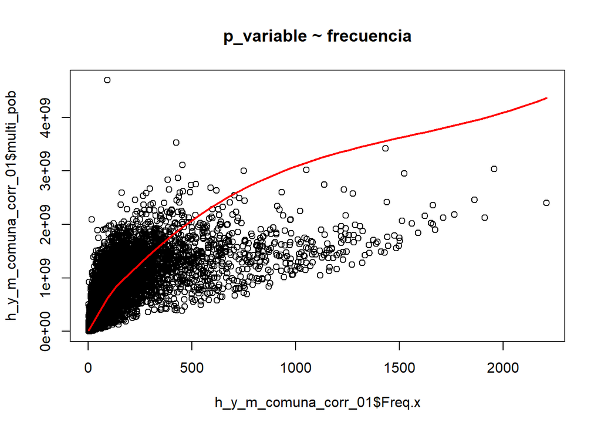

```r
scatter.smooth(x=h_y_m_comuna_corr_01$Freq.x, y=h_y_m_comuna_corr_01$multi_pob, lpars = list(col = "red", lwd = 2, lty = 1), main="p_variable ~ frecuencia")
```

### 5.2 Modelo lineal

```r
linearMod <- lm( multi_pob~Freq.x , data=h_y_m_comuna_corr_01)
summary(linearMod)
```

```
##
## Call:
## lm(formula = multi_pob ~ Freq.x, data = h_y_m_comuna_corr_01)
##
## Residuals:
##        Min         1Q     Median         3Q        Max
## -2.586e+09 -2.108e+08 -1.722e+08  1.511e+08  4.277e+09
##
## Coefficients:
##              Estimate Std. Error t value Pr(>|t|)
## (Intercept) 220065019    3808468   57.78   <2e-16 ***
## Freq.x        2157714      18952  113.85   <2e-16 ***
## ---
## Signif. codes:  0 '***' 0.001 '**' 0.01 '*' 0.05 '.' 0.1 ' ' 1
##
## Residual standard error: 381900000 on 12535 degrees of freedom
##   (134 observations deleted due to missingness)
## Multiple R-squared:  0.5084, Adjusted R-squared:  0.5083
## F-statistic: 1.296e+04 on 1 and 12535 DF,  p-value: < 2.2e-16
```

### 5.3 Gráfica de la recta de regresión lineal

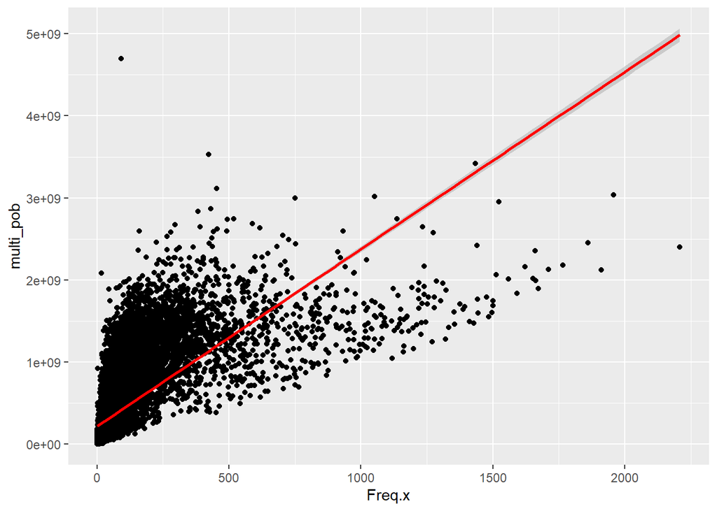

```r
ggplot(h_y_m_comuna_corr_01, aes(x = Freq.x , y = multi_pob)) +
  geom_point() +
  stat_smooth(method = "lm", col = "red")
```

### 5.4 Análisis de los residuos

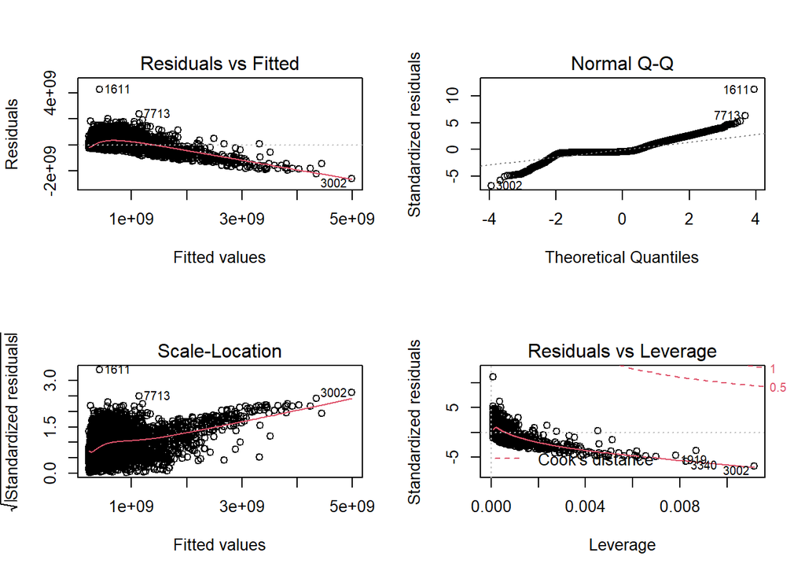

```r
par(mfrow = c (2,2))
plot(linearMod)
```

Al observar el gráfico de residuos versus los valores ajustados del modelo sospechamos que con un modelo alternativo al lineal podemos obtener un coeficiente de determinación más alto.

### 5.5 Modelos alternativos

```r
linearMod <- lm( multi_pob~Freq.x^2 , data=h_y_m_comuna_corr_01)
summary(linearMod)
```

```
##
## Call:
## lm(formula = multi_pob ~ Freq.x^2, data = h_y_m_comuna_corr_01)
##
## Residuals:
##        Min         1Q     Median         3Q        Max
## -2.586e+09 -2.108e+08 -1.722e+08  1.511e+08  4.277e+09
##
## Coefficients:
##              Estimate Std. Error t value Pr(>|t|)
## (Intercept) 220065019    3808468   57.78   <2e-16 ***
## Freq.x        2157714      18952  113.85   <2e-16 ***
## ---
## Signif. codes:  0 '***' 0.001 '**' 0.01 '*' 0.05 '.' 0.1 ' ' 1
##
## Residual standard error: 381900000 on 12535 degrees of freedom
##   (134 observations deleted due to missingness)
## Multiple R-squared:  0.5084, Adjusted R-squared:  0.5083
## F-statistic: 1.296e+04 on 1 and 12535 DF,  p-value: < 2.2e-16
```

#### 5.5.2 Función logarítmica

```r
linearMod <- lm( multi_pob~log(Freq.x) , data=h_y_m_comuna_corr_01)
summary(linearMod)
```

```
##
## Call:
## lm(formula = multi_pob ~ log(Freq.x), data = h_y_m_comuna_corr_01)
##
## Residuals:
##        Min         1Q     Median         3Q        Max
## -772173065 -211415248  -13884959  230586722 3899818817
##
## Coefficients:
##               Estimate Std. Error t value Pr(>|t|)
## (Intercept) -228361031    4781725  -47.76   <2e-16 ***
## log(Freq.x)  226402869    1382158  163.80   <2e-16 ***
## ---
## Signif. codes:  0 '***' 0.001 '**' 0.01 '*' 0.05 '.' 0.1 ' ' 1
##
## Residual standard error: 307300000 on 12535 degrees of freedom
##   (134 observations deleted due to missingness)
## Multiple R-squared:  0.6816, Adjusted R-squared:  0.6816
## F-statistic: 2.683e+04 on 1 and 12535 DF,  p-value: < 2.2e-16
```

```r
linearMod <- lm( multi_pob~Freq.x^3 , data=h_y_m_comuna_corr_01)
summary(linearMod)
```

```
##
## Call:
## lm(formula = multi_pob ~ Freq.x^3, data = h_y_m_comuna_corr_01)
##
## Residuals:
##        Min         1Q     Median         3Q        Max
## -2.586e+09 -2.108e+08 -1.722e+08  1.511e+08  4.277e+09
##
## Coefficients:
##              Estimate Std. Error t value Pr(>|t|)
## (Intercept) 220065019    3808468   57.78   <2e-16 ***
## Freq.x        2157714      18952  113.85   <2e-16 ***
## ---
## Signif. codes:  0 '***' 0.001 '**' 0.01 '*' 0.05 '.' 0.1 ' ' 1
##
## Residual standard error: 381900000 on 12535 degrees of freedom
##   (134 observations deleted due to missingness)
## Multiple R-squared:  0.5084, Adjusted R-squared:  0.5083
## F-statistic: 1.296e+04 on 1 and 12535 DF,  p-value: < 2.2e-16
```

### 5.6 El modelo log

#### 5.6.1 Dispersión del modelo log

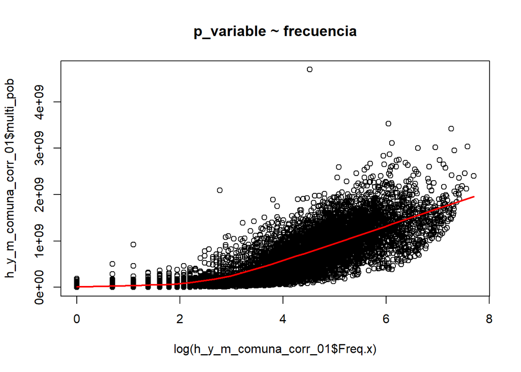

```r
scatter.smooth(x=log(h_y_m_comuna_corr_01$Freq.x), y=h_y_m_comuna_corr_01$multi_pob, lpars = list(col = "red", lwd = 2, lty = 1), main="p_variable ~ frecuencia")
```

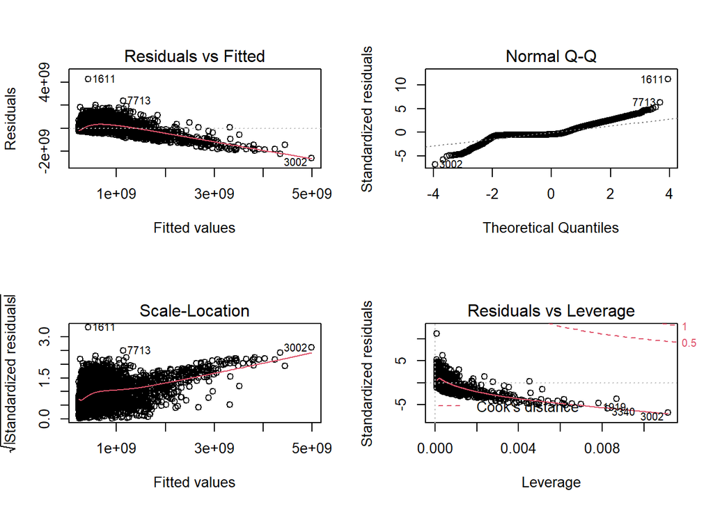

```r
par(mfrow = c (2,2))
plot(linearMod)
```

### 5.7 Tratamiento de NAs y outliers

#### 5.7.1 Existencia y tratamiento de NAs

Descubramos si los campos multi_pob y Freq.x poseen valores NA:

```r
any(is.na(h_y_m_comuna_corr_01$multi_pob))
```

```
## [1] TRUE
```

```r
any(is.na(h_y_m_comuna_corr_01$Freq.x))
```

```
## [1] FALSE
```

Reemplazaremos los valores NAs de multi_pob con sus promedios, generando una nueva columna llamada **multi_pob_mean**:

```r
h_y_m_comuna_corr_01$multi_pob_mean <- ifelse(is.na(h_y_m_comuna_corr_01$multi_pob),
                                   mean(h_y_m_comuna_corr_01$multi_pob, na.rm = TRUE),
                                   h_y_m_comuna_corr_01$multi_pob
                                   )
```

Verificamos de que ya no existen NAs en multi_pob_mean:

```r
any(is.na(h_y_m_comuna_corr_01$multi_pob_mean))
```

```
## [1] FALSE
```

#### 5.7.2 Outliers

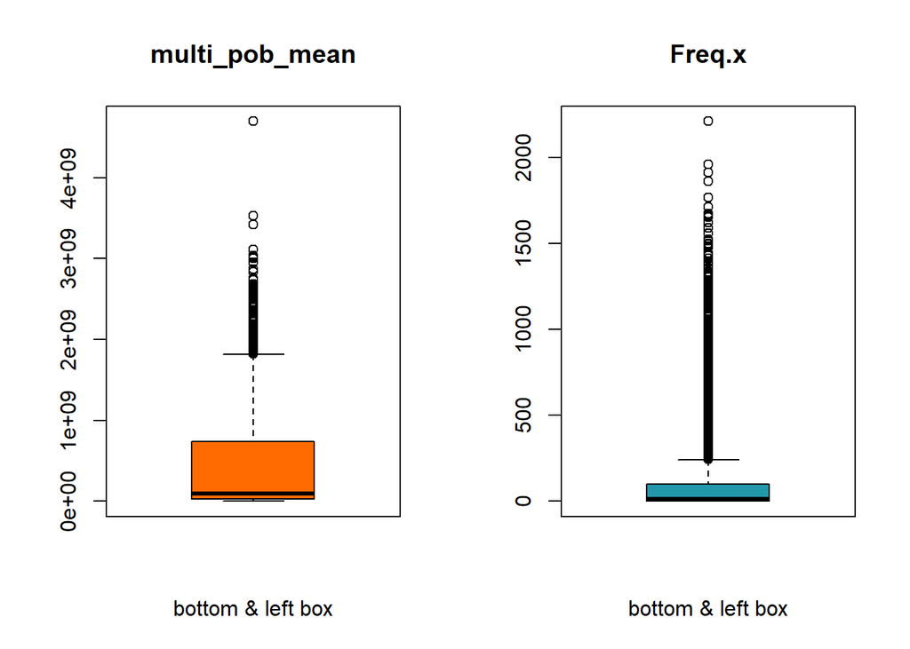

```r
par(mfrow = c(1,2))
boxplot(h_y_m_comuna_corr_01$multi_pob_mean,  col="#FF6B00" , xlab="bottom & left box",
        main = "multi_pob_mean",
        boxwex = 0.9)
boxplot(h_y_m_comuna_corr_01$Freq.x , col="#2398AB" , xlab="bottom & left box",
        main = "Freq.x",
        boxwex = 0.9)
```

#### Eliminación de outliers de **multi_pob_mean**:

```r
Q1 <- quantile(h_y_m_comuna_corr_01$multi_pob_mean, .25)
Q3 <- quantile(h_y_m_comuna_corr_01$multi_pob_mean, .75)
IQR <- IQR(h_y_m_comuna_corr_01$multi_pob_mean)
no_outliers <- subset(h_y_m_comuna_corr_01, h_y_m_comuna_corr_01$multi_pob_mean> (Q1 - 1.5*IQR) & h_y_m_comuna_corr_01$multi_pob_mean< (Q3 + 1.5*IQR))
```

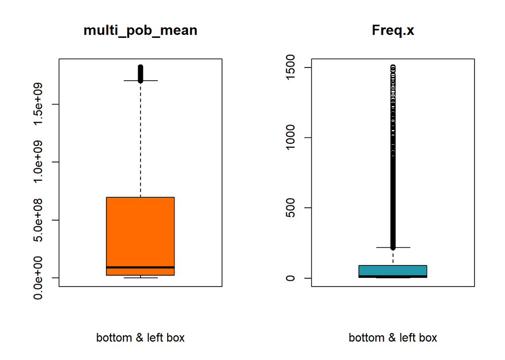

```r
par(mfrow = c(1,2))
boxplot(no_outliers$multi_pob_mean,  col="#FF6B00" , xlab="bottom & left box",
        main = "multi_pob_mean",
        boxwex = 0.9)
boxplot(no_outliers$Freq.x , col="#2398AB" , xlab="bottom & left box",
        main = "Freq.x",
        boxwex = 0.9)
```

#### Eliminación de outliers de **Freq.x**:

```r
Q1 <- quantile(no_outliers$Freq.x, .25)
Q3 <- quantile(no_outliers$Freq.x, .75)
IQR <- IQR(no_outliers$Freq.x)
no_outliers_2 <- subset(no_outliers, no_outliers$Freq.x> (Q1 - 1.5*IQR) & no_outliers$Freq.x< (Q3 + 1.5*IQR))
```

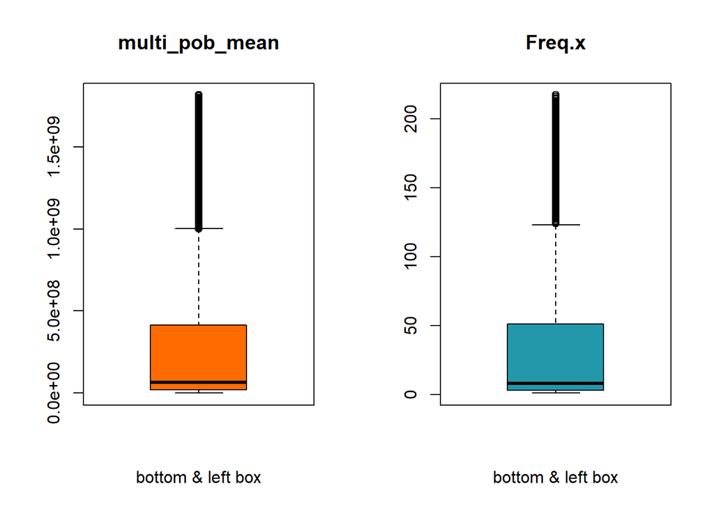

```r
par(mfrow = c(1,2))
boxplot(no_outliers_2$multi_pob_mean,  col="#FF6B00" , xlab="bottom & left box",
        main = "multi_pob_mean",
        boxwex = 0.9)
boxplot(no_outliers_2$Freq.x , col="#2398AB" , xlab="bottom & left box",
        main = "Freq.x",
        boxwex = 0.9)
```

Ejecutemos nuevamente nuestro procedimiento:

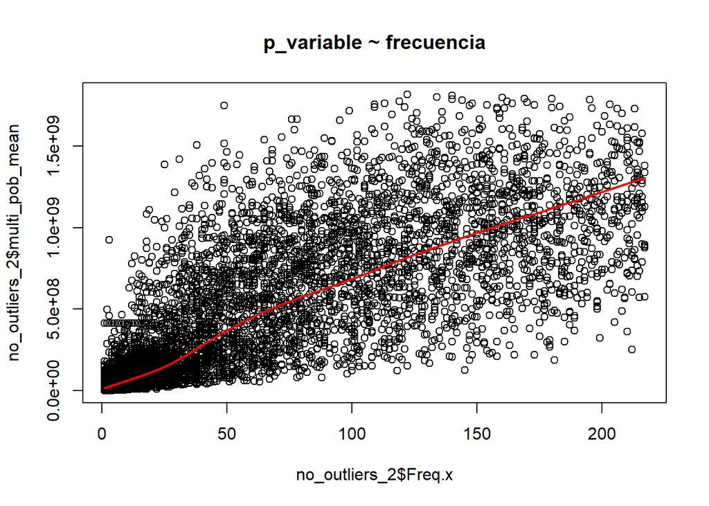

```r
scatter.smooth(x=no_outliers_2$Freq.x, y=no_outliers_2$multi_pob_mean, lpars = list(col = "red", lwd = 2, lty = 1), main="p_variable ~ frecuencia")
```

```r
linearMod <- lm( multi_pob_mean~log(Freq.x) , data=no_outliers_2)
summary(linearMod)
```

```
##
## Call:
## lm(formula = multi_pob_mean ~ log(Freq.x), data = no_outliers_2)
##
## Residuals:
##        Min         1Q     Median         3Q        Max
## -628070607 -177160477  -29234096  157817357 1191864668
##
## Coefficients:
##               Estimate Std. Error t value Pr(>|t|)
## (Intercept) -151719468    4159009  -36.48   <2e-16 ***
## log(Freq.x)  182047668    1426690  127.60   <2e-16 ***
## ---
## Signif. codes:  0 '***' 0.001 '**' 0.01 '*' 0.05 '.' 0.1 ' ' 1
##
## Residual standard error: 254600000 on 11119 degrees of freedom
## Multiple R-squared:  0.5942, Adjusted R-squared:  0.5942
## F-statistic: 1.628e+04 on 1 and 11119 DF,  p-value: < 2.2e-16
```

### 5.8 Aplicación la regresión a los valores de la variable a nivel de zona

Obtuvimos que nuestro mejor modelo fué el logaritmico:

```r
linearMod <- lm( multi_pob~log(Freq.x) , data=h_y_m_comuna_corr_01)
summary(linearMod)
```

```
##
## Call:
## lm(formula = multi_pob ~ log(Freq.x), data = h_y_m_comuna_corr_01)
##
## Residuals:
##        Min         1Q     Median         3Q        Max
## -772173065 -211415248  -13884959  230586722 3899818817
##
## Coefficients:
##               Estimate Std. Error t value Pr(>|t|)
## (Intercept) -228361031    4781725  -47.76   <2e-16 ***
## log(Freq.x)  226402869    1382158  163.80   <2e-16 ***
## ---
## Signif. codes:  0 '***' 0.001 '**' 0.01 '*' 0.05 '.' 0.1 ' ' 1
##
## Residual standard error: 307300000 on 12535 degrees of freedom
##   (134 observations deleted due to missingness)
## Multiple R-squared:  0.6816, Adjusted R-squared:  0.6816
## F-statistic: 2.683e+04 on 1 and 12535 DF,  p-value: < 2.2e-16
```

por lo que nuestra ecuación de regresión será:

$$multi\_pob = -228361031 + 226402869 \cdot \ln (Freq.x)$$

Esta nueva variable se llamará: est_ing

```r
h_y_m_comuna_corr_01$est_ing <- -228361031 + 226402869*  log(h_y_m_comuna_corr_01$Freq.x)
r3_100 <- h_y_m_comuna_corr_01[c(1:100),]
kbl(r3_100) %>%
  kable_styling(bootstrap_options = c("striped", "hover")) %>%
  kable_paper() %>%
  scroll_box(width = "100%", height = "300px")
```

| zona | código.x | Freq.x | anio | p | comuna.x | promedio_i | año | comuna.y | personas | Ingresos_expandidos | Freq.y | p_poblacional | código.y | multi_pob | p_variable | multi_pob_mean | est_ing |
| --- | --- | --- | --- | --- | --- | --- | --- | --- | --- | --- | --- | --- | --- | --- | --- | --- | --- |
| 10101011001 | 10101 | 60 | 2017 | 0.0055366 | Puerto Montt | 268732.4 | 2017 | 10101 | 245902 | 66081845388 | 584 | 0.0023749 | 10101 | 156939747 | 0.0002440 | 156939747 | 698610325 |
| 10101011002 | 10101 | 177 | 2017 | 0.0163329 | Puerto Montt | 268732.4 | 2017 | 10101 | 245902 | 66081845388 | 2941 | 0.0119600 | 10101 | 790342117 | 0.0007198 | 790342117 | 943534119 |
| 10101021001 | 10101 | 82 | 2017 | 0.0075667 | Puerto Montt | 268732.4 | 2017 | 10101 | 245902 | 66081845388 | 3953 | 0.0160755 | 10101 | 1062299350 | 0.0003335 | 1062299350 | 769332849 |
| 10101021002 | 10101 | 77 | 2017 | 0.0071053 | Puerto Montt | 268732.4 | 2017 | 10101 | 245902 | 66081845388 | 1107 | 0.0045018 | 10101 | 297486815 | 0.0003131 | 297486815 | 755088979 |
| 10101021003 | 10101 | 70 | 2017 | 0.0064594 | Puerto Montt | 268732.4 | 2017 | 10101 | 245902 | 66081845388 | 2294 | 0.0093289 | 10101 | 616472226 | 0.0002847 | 616472226 | 733510481 |
| 10101021004 | 10101 | 99 | 2017 | 0.0091354 | Puerto Montt | 268732.4 | 2017 | 10101 | 245902 | 66081845388 | 3391 | 0.0137900 | 10101 | 911271717 | 0.0004026 | 911271717 | 811987286 |
| 10101021005 | 10101 | 171 | 2017 | 0.0157793 | Puerto Montt | 268732.4 | 2017 | 10101 | 245902 | 66081845388 | 2564 | 0.0104269 | 10101 | 689029986 | 0.0006954 | 689029986 | 935726350 |
| 10101031001 | 10101 | 133 | 2017 | 0.0122728 | Puerto Montt | 268732.4 | 2017 | 10101 | 245902 | 66081845388 | 4530 | 0.0184220 | 10101 | 1217357970 | 0.0005409 | 1217357970 | 878828042 |
| 10101031002 | 10101 | 115 | 2017 | 0.0106118 | Puerto Montt | 268732.4 | 2017 | 10101 | 245902 | 66081845388 | 4740 | 0.0192760 | 10101 | 1273791783 | 0.0004677 | 1273791783 | 845905216 |
| 10101031003 | 10101 | 94 | 2017 | 0.0086740 | Puerto Montt | 268732.4 | 2017 | 10101 | 245902 | 66081845388 | 4107 | 0.0167018 | 10101 | 1103684147 | 0.0003823 | 1103684147 | 800253942 |
| 10101031004 | 10101 | 88 | 2017 | 0.0081203 | Puerto Montt | 268732.4 | 2017 | 10101 | 245902 | 66081845388 | 2856 | 0.0116144 | 10101 | 767499859 | 0.0003579 | 767499859 | 785320869 |
| 10101031005 | 10101 | 146 | 2017 | 0.0134724 | Puerto Montt | 268732.4 | 2017 | 10101 | 245902 | 66081845388 | 5690 | 0.0231393 | 10101 | 1529087605 | 0.0005937 | 1529087605 | 899941806 |
| 10101031006 | 10101 | 94 | 2017 | 0.0086740 | Puerto Montt | 268732.4 | 2017 | 10101 | 245902 | 66081845388 | 2460 | 0.0100040 | 10101 | 661081812 | 0.0003823 | 661081812 | 800253942 |
| 10101031007 | 10101 | 39 | 2017 | 0.0035988 | Puerto Montt | 268732.4 | 2017 | 10101 | 245902 | 66081845388 | 2292 | 0.0093208 | 10101 | 615934761 | 0.0001586 | 615934761 | 601079836 |
| 10101031008 | 10101 | 54 | 2017 | 0.0049829 | Puerto Montt | 268732.4 | 2017 | 10101 | 245902 | 66081845388 | 3585 | 0.0145790 | 10101 | 963405811 | 0.0002196 | 963405811 | 674756402 |
| 10101031009 | 10101 | 166 | 2017 | 0.0153179 | Puerto Montt | 268732.4 | 2017 | 10101 | 245902 | 66081845388 | 4436 | 0.0180397 | 10101 | 1192097121 | 0.0006751 | 1192097121 | 929007671 |
| 10101031010 | 10101 | 92 | 2017 | 0.0084894 | Puerto Montt | 268732.4 | 2017 | 10101 | 245902 | 66081845388 | 3566 | 0.0145017 | 10101 | 958299894 | 0.0003741 | 958299894 | 795384876 |
| 10101031011 | 10101 | 49 | 2017 | 0.0045215 | Puerto Montt | 268732.4 | 2017 | 10101 | 245902 | 66081845388 | 2757 | 0.0112118 | 10101 | 740895347 | 0.0001993 | 740895347 | 652758250 |
| 10101031012 | 10101 | 94 | 2017 | 0.0086740 | Puerto Montt | 268732.4 | 2017 | 10101 | 245902 | 66081845388 | 1849 | 0.0075193 | 10101 | 496886289 | 0.0003823 | 496886289 | 800253942 |
| 10101031013 | 10101 | 73 | 2017 | 0.0067362 | Puerto Montt | 268732.4 | 2017 | 10101 | 245902 | 66081845388 | 3945 | 0.0160430 | 10101 | 1060149491 | 0.0002969 | 1060149491 | 743011296 |
| 10101031014 | 10101 | 109 | 2017 | 0.0100581 | Puerto Montt | 268732.4 | 2017 | 10101 | 245902 | 66081845388 | 2265 | 0.0092110 | 10101 | 608678985 | 0.0004433 | 608678985 | 833773589 |
| 10101031015 | 10101 | 31 | 2017 | 0.0028606 | Puerto Montt | 268732.4 | 2017 | 10101 | 245902 | 66081845388 | 1930 | 0.0078487 | 10101 | 518653616 | 0.0001261 | 518653616 | 549103524 |
| 10101031016 | 10101 | 248 | 2017 | 0.0228846 | Puerto Montt | 268732.4 | 2017 | 10101 | 245902 | 66081845388 | 3071 | 0.0124887 | 10101 | 825277335 | 0.0010085 | 825277335 | 1019895055 |
| 10101031017 | 10101 | 60 | 2017 | 0.0055366 | Puerto Montt | 268732.4 | 2017 | 10101 | 245902 | 66081845388 | 3885 | 0.0157990 | 10101 | 1044025544 | 0.0002440 | 1044025544 | 698610325 |
| 10101032002 | 10101 | 2 | 2017 | 0.0001846 | Puerto Montt | 268732.4 | 2017 | 10101 | 245902 | 66081845388 | 129 | 0.0005246 | 10101 | 34666485 | 0.0000081 | 34666485 | -71430521 |
| 10101032011 | 10101 | 20 | 2017 | 0.0018455 | Puerto Montt | 268732.4 | 2017 | 10101 | 245902 | 66081845388 | 426 | 0.0017324 | 10101 | 114480021 | 0.0000813 | 114480021 | 449881350 |
| 10101032019 | 10101 | 32 | 2017 | 0.0029528 | Puerto Montt | 268732.4 | 2017 | 10101 | 245902 | 66081845388 | 829 | 0.0033713 | 10101 | 222779196 | 0.0001301 | 222779196 | 556291521 |
| 10101041001 | 10101 | 70 | 2017 | 0.0064594 | Puerto Montt | 268732.4 | 2017 | 10101 | 245902 | 66081845388 | 4342 | 0.0176574 | 10101 | 1166836271 | 0.0002847 | 1166836271 | 733510481 |
| 10101041002 | 10101 | 55 | 2017 | 0.0050752 | Puerto Montt | 268732.4 | 2017 | 10101 | 245902 | 66081845388 | 2169 | 0.0088206 | 10101 | 582880671 | 0.0002237 | 582880671 | 678910699 |
| 10101041003 | 10101 | 774 | 2017 | 0.0714220 | Puerto Montt | 268732.4 | 2017 | 10101 | 245902 | 66081845388 | 5202 | 0.0211548 | 10101 | 1397946172 | 0.0031476 | 1397946172 | 1277573925 |

[output cut: 70 more lines]

### 5.9 División del valor estimado entre la población total de la zona para obtener el ingreso medio por zona

$$Ingreso Medio/zona = est\_ing / (personas * p\_poblacional)$$

```r
h_y_m_comuna_corr_01$ing_medio_zona <- h_y_m_comuna_corr_01$est_ing  /( h_y_m_comuna_corr_01$personas  * h_y_m_comuna_corr_01$p_poblacional)

r3_100 <- h_y_m_comuna_corr_01[c(1:100),]
kbl(r3_100) %>%
  kable_styling(bootstrap_options = c("striped", "hover")) %>%
  kable_paper() %>%
  scroll_box(width = "100%", height = "300px")
```

| zona | código.x | Freq.x | anio | p | comuna.x | promedio_i | año | comuna.y | personas | Ingresos_expandidos | Freq.y | p_poblacional | código.y | multi_pob | p_variable | multi_pob_mean | est_ing | ing_medio_zona |
| --- | --- | --- | --- | --- | --- | --- | --- | --- | --- | --- | --- | --- | --- | --- | --- | --- | --- | --- |
| 10101011001 | 10101 | 60 | 2017 | 0.0055366 | Puerto Montt | 268732.4 | 2017 | 10101 | 245902 | 66081845388 | 584 | 0.0023749 | 10101 | 156939747 | 0.0002440 | 156939747 | 698610325 | 1196250.6 |
| 10101011002 | 10101 | 177 | 2017 | 0.0163329 | Puerto Montt | 268732.4 | 2017 | 10101 | 245902 | 66081845388 | 2941 | 0.0119600 | 10101 | 790342117 | 0.0007198 | 790342117 | 943534119 | 320820.8 |
| 10101021001 | 10101 | 82 | 2017 | 0.0075667 | Puerto Montt | 268732.4 | 2017 | 10101 | 245902 | 66081845388 | 3953 | 0.0160755 | 10101 | 1062299350 | 0.0003335 | 1062299350 | 769332849 | 194620.0 |
| 10101021002 | 10101 | 77 | 2017 | 0.0071053 | Puerto Montt | 268732.4 | 2017 | 10101 | 245902 | 66081845388 | 1107 | 0.0045018 | 10101 | 297486815 | 0.0003131 | 297486815 | 755088979 | 682103.9 |
| 10101021003 | 10101 | 70 | 2017 | 0.0064594 | Puerto Montt | 268732.4 | 2017 | 10101 | 245902 | 66081845388 | 2294 | 0.0093289 | 10101 | 616472226 | 0.0002847 | 616472226 | 733510481 | 319751.7 |
| 10101021004 | 10101 | 99 | 2017 | 0.0091354 | Puerto Montt | 268732.4 | 2017 | 10101 | 245902 | 66081845388 | 3391 | 0.0137900 | 10101 | 911271717 | 0.0004026 | 911271717 | 811987286 | 239453.6 |
| 10101021005 | 10101 | 171 | 2017 | 0.0157793 | Puerto Montt | 268732.4 | 2017 | 10101 | 245902 | 66081845388 | 2564 | 0.0104269 | 10101 | 689029986 | 0.0006954 | 689029986 | 935726350 | 364947.9 |
| 10101031001 | 10101 | 133 | 2017 | 0.0122728 | Puerto Montt | 268732.4 | 2017 | 10101 | 245902 | 66081845388 | 4530 | 0.0184220 | 10101 | 1217357970 | 0.0005409 | 1217357970 | 878828042 | 194001.8 |
| 10101031002 | 10101 | 115 | 2017 | 0.0106118 | Puerto Montt | 268732.4 | 2017 | 10101 | 245902 | 66081845388 | 4740 | 0.0192760 | 10101 | 1273791783 | 0.0004677 | 1273791783 | 845905216 | 178461.0 |
| 10101031003 | 10101 | 94 | 2017 | 0.0086740 | Puerto Montt | 268732.4 | 2017 | 10101 | 245902 | 66081845388 | 4107 | 0.0167018 | 10101 | 1103684147 | 0.0003823 | 1103684147 | 800253942 | 194851.2 |
| 10101031004 | 10101 | 88 | 2017 | 0.0081203 | Puerto Montt | 268732.4 | 2017 | 10101 | 245902 | 66081845388 | 2856 | 0.0116144 | 10101 | 767499859 | 0.0003579 | 767499859 | 785320869 | 274972.3 |
| 10101031005 | 10101 | 146 | 2017 | 0.0134724 | Puerto Montt | 268732.4 | 2017 | 10101 | 245902 | 66081845388 | 5690 | 0.0231393 | 10101 | 1529087605 | 0.0005937 | 1529087605 | 899941806 | 158162.0 |
| 10101031006 | 10101 | 94 | 2017 | 0.0086740 | Puerto Montt | 268732.4 | 2017 | 10101 | 245902 | 66081845388 | 2460 | 0.0100040 | 10101 | 661081812 | 0.0003823 | 661081812 | 800253942 | 325306.5 |
| 10101031007 | 10101 | 39 | 2017 | 0.0035988 | Puerto Montt | 268732.4 | 2017 | 10101 | 245902 | 66081845388 | 2292 | 0.0093208 | 10101 | 615934761 | 0.0001586 | 615934761 | 601079836 | 262251.2 |
| 10101031008 | 10101 | 54 | 2017 | 0.0049829 | Puerto Montt | 268732.4 | 2017 | 10101 | 245902 | 66081845388 | 3585 | 0.0145790 | 10101 | 963405811 | 0.0002196 | 963405811 | 674756402 | 188216.6 |
| 10101031009 | 10101 | 166 | 2017 | 0.0153179 | Puerto Montt | 268732.4 | 2017 | 10101 | 245902 | 66081845388 | 4436 | 0.0180397 | 10101 | 1192097121 | 0.0006751 | 1192097121 | 929007671 | 209424.6 |
| 10101031010 | 10101 | 92 | 2017 | 0.0084894 | Puerto Montt | 268732.4 | 2017 | 10101 | 245902 | 66081845388 | 3566 | 0.0145017 | 10101 | 958299894 | 0.0003741 | 958299894 | 795384876 | 223046.8 |
| 10101031011 | 10101 | 49 | 2017 | 0.0045215 | Puerto Montt | 268732.4 | 2017 | 10101 | 245902 | 66081845388 | 2757 | 0.0112118 | 10101 | 740895347 | 0.0001993 | 740895347 | 652758250 | 236764.0 |
| 10101031012 | 10101 | 94 | 2017 | 0.0086740 | Puerto Montt | 268732.4 | 2017 | 10101 | 245902 | 66081845388 | 1849 | 0.0075193 | 10101 | 496886289 | 0.0003823 | 496886289 | 800253942 | 432803.6 |
| 10101031013 | 10101 | 73 | 2017 | 0.0067362 | Puerto Montt | 268732.4 | 2017 | 10101 | 245902 | 66081845388 | 3945 | 0.0160430 | 10101 | 1060149491 | 0.0002969 | 1060149491 | 743011296 | 188342.5 |
| 10101031014 | 10101 | 109 | 2017 | 0.0100581 | Puerto Montt | 268732.4 | 2017 | 10101 | 245902 | 66081845388 | 2265 | 0.0092110 | 10101 | 608678985 | 0.0004433 | 608678985 | 833773589 | 368112.0 |
| 10101031015 | 10101 | 31 | 2017 | 0.0028606 | Puerto Montt | 268732.4 | 2017 | 10101 | 245902 | 66081845388 | 1930 | 0.0078487 | 10101 | 518653616 | 0.0001261 | 518653616 | 549103524 | 284509.6 |
| 10101031016 | 10101 | 248 | 2017 | 0.0228846 | Puerto Montt | 268732.4 | 2017 | 10101 | 245902 | 66081845388 | 3071 | 0.0124887 | 10101 | 825277335 | 0.0010085 | 825277335 | 1019895055 | 332105.2 |
| 10101031017 | 10101 | 60 | 2017 | 0.0055366 | Puerto Montt | 268732.4 | 2017 | 10101 | 245902 | 66081845388 | 3885 | 0.0157990 | 10101 | 1044025544 | 0.0002440 | 1044025544 | 698610325 | 179822.5 |
| 10101032002 | 10101 | 2 | 2017 | 0.0001846 | Puerto Montt | 268732.4 | 2017 | 10101 | 245902 | 66081845388 | 129 | 0.0005246 | 10101 | 34666485 | 0.0000081 | 34666485 | -71430521 | -553725.0 |
| 10101032011 | 10101 | 20 | 2017 | 0.0018455 | Puerto Montt | 268732.4 | 2017 | 10101 | 245902 | 66081845388 | 426 | 0.0017324 | 10101 | 114480021 | 0.0000813 | 114480021 | 449881350 | 1056059.5 |
| 10101032019 | 10101 | 32 | 2017 | 0.0029528 | Puerto Montt | 268732.4 | 2017 | 10101 | 245902 | 66081845388 | 829 | 0.0033713 | 10101 | 222779196 | 0.0001301 | 222779196 | 556291521 | 671039.2 |
| 10101041001 | 10101 | 70 | 2017 | 0.0064594 | Puerto Montt | 268732.4 | 2017 | 10101 | 245902 | 66081845388 | 4342 | 0.0176574 | 10101 | 1166836271 | 0.0002847 | 1166836271 | 733510481 | 168933.8 |
| 10101041002 | 10101 | 55 | 2017 | 0.0050752 | Puerto Montt | 268732.4 | 2017 | 10101 | 245902 | 66081845388 | 2169 | 0.0088206 | 10101 | 582880671 | 0.0002237 | 582880671 | 678910699 | 313006.3 |
| 10101041003 | 10101 | 774 | 2017 | 0.0714220 | Puerto Montt | 268732.4 | 2017 | 10101 | 245902 | 66081845388 | 5202 | 0.0211548 | 10101 | 1397946172 | 0.0031476 | 1397946172 | 1277573925 | 245592.8 |

[output cut: 70 more lines]

## 6 Coeficientes de la regresión lineal de multi_pob sobre p_variable

Donde:

$$Y(dependiente) = ingreso\_expandido\_por\_zona (multi\_pob)$$

$$X(independiente) = porcentaje\_de\_poblacion\_respecto\_a\_la\_zona (p\_variable)$$

### 6.1 Diagrama de dispersión

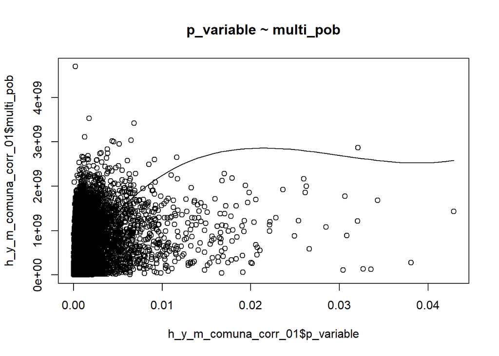

```r
scatter.smooth(x=h_y_m_comuna_corr_01$p_variable, y=h_y_m_comuna_corr_01$multi_pob, main="p_variable ~ multi_pob")
```

### 6.2 Observación de outliers mediante diagrama de caja y bigotes.

Cualquier punto que se encuentre fuera del rango +/- 1.5 * IQR se considera un valor atípico donde, IQR (rango intercuartílico) se calcula como la distancia entre los valores del percentil 25 y el percentil 75 para esa variable.

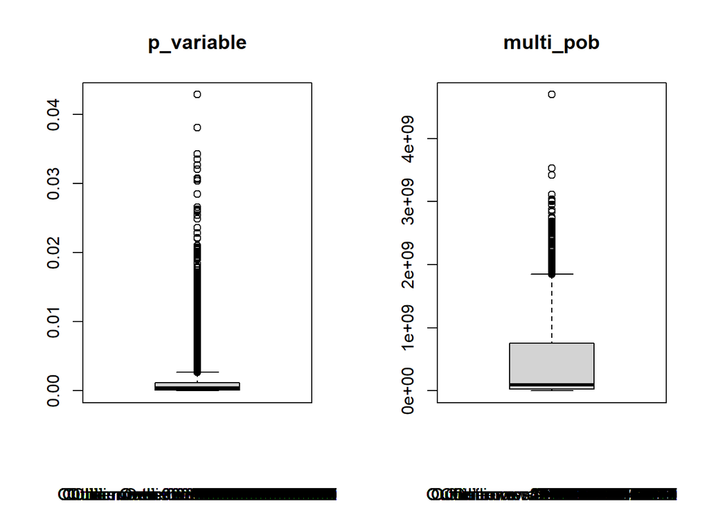

```r
par(mfrow=c(1, 2))  # divide graph area in 2 columns
boxplot(h_y_m_comuna_corr_01$p_variable, main="p_variable", sub=paste("Outlier rows: ", boxplot.stats(h_y_m_comuna_corr_01$p_variable)$out))  # box plot for 'speed'
boxplot(h_y_m_comuna_corr_01$multi_pob, main="multi_pob", sub=paste("Outlier rows: ", boxplot.stats(h_y_m_comuna_corr_01$multi_pob)$out))
```

### 6.3 Modelo lineal

```r
linearMod <- lm( multi_pob~p_variable , data=h_y_m_comuna_corr_01)
```

```r
summary(linearMod)
```

```
##
## Call:
## lm(formula = multi_pob ~ p_variable, data = h_y_m_comuna_corr_01)
##
## Residuals:
##        Min         1Q     Median         3Q        Max
## -3.216e+09 -3.150e+08 -2.725e+08  2.788e+08  4.358e+09
##
## Coefficients:
##              Estimate Std. Error t value Pr(>|t|)
## (Intercept) 3.179e+08  5.044e+06   63.03   <2e-16 ***
## p_variable  8.328e+10  1.928e+09   43.19   <2e-16 ***
## ---
## Signif. codes:  0 '***' 0.001 '**' 0.01 '*' 0.05 '.' 0.1 ' ' 1
##
## Residual standard error: 508200000 on 12535 degrees of freedom
##   (134 observations deleted due to missingness)
## Multiple R-squared:  0.1295, Adjusted R-squared:  0.1294
## F-statistic:  1865 on 1 and 12535 DF,  p-value: < 2.2e-16
```

$$Y = 3.179e08 + 8.328e10 \cdot X$$

### 6.4 Aplicación la regresión a los valores de la variable a nivel de zona

$$Y = 3.179e08 + 8.328e10 \cdot p\_variable$$
Esta nueva variable se llamará: est_ing

```r
h_y_m_comuna_corr_01$est_ing <- 3.179e+08 + 8.328e+10* h_y_m_comuna_corr_01$p_variable
```

```r
r3_100 <- h_y_m_comuna_corr_01[c(1:100),]
kbl(r3_100) %>%
  kable_styling(bootstrap_options = c("striped", "hover")) %>%
  kable_paper() %>%
  scroll_box(width = "100%", height = "300px")
```

| zona | código.x | Freq.x | anio | p | comuna.x | promedio_i | año | comuna.y | personas | Ingresos_expandidos | Freq.y | p_poblacional | código.y | multi_pob | p_variable | multi_pob_mean | est_ing | ing_medio_zona |
| --- | --- | --- | --- | --- | --- | --- | --- | --- | --- | --- | --- | --- | --- | --- | --- | --- | --- | --- |
| 10101011001 | 10101 | 60 | 2017 | 0.0055366 | Puerto Montt | 268732.4 | 2017 | 10101 | 245902 | 66081845388 | 584 | 0.0023749 | 10101 | 156939747 | 0.0002440 | 156939747 | 338220290 | 1196250.6 |
| 10101011002 | 10101 | 177 | 2017 | 0.0163329 | Puerto Montt | 268732.4 | 2017 | 10101 | 245902 | 66081845388 | 2941 | 0.0119600 | 10101 | 790342117 | 0.0007198 | 790342117 | 377844856 | 320820.8 |
| 10101021001 | 10101 | 82 | 2017 | 0.0075667 | Puerto Montt | 268732.4 | 2017 | 10101 | 245902 | 66081845388 | 3953 | 0.0160755 | 10101 | 1062299350 | 0.0003335 | 1062299350 | 345671063 | 194620.0 |
| 10101021002 | 10101 | 77 | 2017 | 0.0071053 | Puerto Montt | 268732.4 | 2017 | 10101 | 245902 | 66081845388 | 1107 | 0.0045018 | 10101 | 297486815 | 0.0003131 | 297486815 | 343977706 | 682103.9 |
| 10101021003 | 10101 | 70 | 2017 | 0.0064594 | Puerto Montt | 268732.4 | 2017 | 10101 | 245902 | 66081845388 | 2294 | 0.0093289 | 10101 | 616472226 | 0.0002847 | 616472226 | 341607005 | 319751.7 |
| 10101021004 | 10101 | 99 | 2017 | 0.0091354 | Puerto Montt | 268732.4 | 2017 | 10101 | 245902 | 66081845388 | 3391 | 0.0137900 | 10101 | 911271717 | 0.0004026 | 911271717 | 351428479 | 239453.6 |
| 10101021005 | 10101 | 171 | 2017 | 0.0157793 | Puerto Montt | 268732.4 | 2017 | 10101 | 245902 | 66081845388 | 2564 | 0.0104269 | 10101 | 689029986 | 0.0006954 | 689029986 | 375812827 | 364947.9 |
| 10101031001 | 10101 | 133 | 2017 | 0.0122728 | Puerto Montt | 268732.4 | 2017 | 10101 | 245902 | 66081845388 | 4530 | 0.0184220 | 10101 | 1217357970 | 0.0005409 | 1217357970 | 362943310 | 194001.8 |
| 10101031002 | 10101 | 115 | 2017 | 0.0106118 | Puerto Montt | 268732.4 | 2017 | 10101 | 245902 | 66081845388 | 4740 | 0.0192760 | 10101 | 1273791783 | 0.0004677 | 1273791783 | 356847223 | 178461.0 |
| 10101031003 | 10101 | 94 | 2017 | 0.0086740 | Puerto Montt | 268732.4 | 2017 | 10101 | 245902 | 66081845388 | 4107 | 0.0167018 | 10101 | 1103684147 | 0.0003823 | 1103684147 | 349735121 | 194851.2 |
| 10101031004 | 10101 | 88 | 2017 | 0.0081203 | Puerto Montt | 268732.4 | 2017 | 10101 | 245902 | 66081845388 | 2856 | 0.0116144 | 10101 | 767499859 | 0.0003579 | 767499859 | 347703092 | 274972.3 |
| 10101031005 | 10101 | 146 | 2017 | 0.0134724 | Puerto Montt | 268732.4 | 2017 | 10101 | 245902 | 66081845388 | 5690 | 0.0231393 | 10101 | 1529087605 | 0.0005937 | 1529087605 | 367346039 | 158162.0 |
| 10101031006 | 10101 | 94 | 2017 | 0.0086740 | Puerto Montt | 268732.4 | 2017 | 10101 | 245902 | 66081845388 | 2460 | 0.0100040 | 10101 | 661081812 | 0.0003823 | 661081812 | 349735121 | 325306.5 |
| 10101031007 | 10101 | 39 | 2017 | 0.0035988 | Puerto Montt | 268732.4 | 2017 | 10101 | 245902 | 66081845388 | 2292 | 0.0093208 | 10101 | 615934761 | 0.0001586 | 615934761 | 331108189 | 262251.2 |
| 10101031008 | 10101 | 54 | 2017 | 0.0049829 | Puerto Montt | 268732.4 | 2017 | 10101 | 245902 | 66081845388 | 3585 | 0.0145790 | 10101 | 963405811 | 0.0002196 | 963405811 | 336188261 | 188216.6 |
| 10101031009 | 10101 | 166 | 2017 | 0.0153179 | Puerto Montt | 268732.4 | 2017 | 10101 | 245902 | 66081845388 | 4436 | 0.0180397 | 10101 | 1192097121 | 0.0006751 | 1192097121 | 374119470 | 209424.6 |
| 10101031010 | 10101 | 92 | 2017 | 0.0084894 | Puerto Montt | 268732.4 | 2017 | 10101 | 245902 | 66081845388 | 3566 | 0.0145017 | 10101 | 958299894 | 0.0003741 | 958299894 | 349057778 | 223046.8 |
| 10101031011 | 10101 | 49 | 2017 | 0.0045215 | Puerto Montt | 268732.4 | 2017 | 10101 | 245902 | 66081845388 | 2757 | 0.0112118 | 10101 | 740895347 | 0.0001993 | 740895347 | 334494904 | 236764.0 |
| 10101031012 | 10101 | 94 | 2017 | 0.0086740 | Puerto Montt | 268732.4 | 2017 | 10101 | 245902 | 66081845388 | 1849 | 0.0075193 | 10101 | 496886289 | 0.0003823 | 496886289 | 349735121 | 432803.6 |
| 10101031013 | 10101 | 73 | 2017 | 0.0067362 | Puerto Montt | 268732.4 | 2017 | 10101 | 245902 | 66081845388 | 3945 | 0.0160430 | 10101 | 1060149491 | 0.0002969 | 1060149491 | 342623020 | 188342.5 |
| 10101031014 | 10101 | 109 | 2017 | 0.0100581 | Puerto Montt | 268732.4 | 2017 | 10101 | 245902 | 66081845388 | 2265 | 0.0092110 | 10101 | 608678985 | 0.0004433 | 608678985 | 354815194 | 368112.0 |
| 10101031015 | 10101 | 31 | 2017 | 0.0028606 | Puerto Montt | 268732.4 | 2017 | 10101 | 245902 | 66081845388 | 1930 | 0.0078487 | 10101 | 518653616 | 0.0001261 | 518653616 | 328398817 | 284509.6 |
| 10101031016 | 10101 | 248 | 2017 | 0.0228846 | Puerto Montt | 268732.4 | 2017 | 10101 | 245902 | 66081845388 | 3071 | 0.0124887 | 10101 | 825277335 | 0.0010085 | 825277335 | 401890533 | 332105.2 |
| 10101031017 | 10101 | 60 | 2017 | 0.0055366 | Puerto Montt | 268732.4 | 2017 | 10101 | 245902 | 66081845388 | 3885 | 0.0157990 | 10101 | 1044025544 | 0.0002440 | 1044025544 | 338220290 | 179822.5 |
| 10101032002 | 10101 | 2 | 2017 | 0.0001846 | Puerto Montt | 268732.4 | 2017 | 10101 | 245902 | 66081845388 | 129 | 0.0005246 | 10101 | 34666485 | 0.0000081 | 34666485 | 318577343 | -553725.0 |
| 10101032011 | 10101 | 20 | 2017 | 0.0018455 | Puerto Montt | 268732.4 | 2017 | 10101 | 245902 | 66081845388 | 426 | 0.0017324 | 10101 | 114480021 | 0.0000813 | 114480021 | 324673430 | 1056059.5 |
| 10101032019 | 10101 | 32 | 2017 | 0.0029528 | Puerto Montt | 268732.4 | 2017 | 10101 | 245902 | 66081845388 | 829 | 0.0033713 | 10101 | 222779196 | 0.0001301 | 222779196 | 328737488 | 671039.2 |
| 10101041001 | 10101 | 70 | 2017 | 0.0064594 | Puerto Montt | 268732.4 | 2017 | 10101 | 245902 | 66081845388 | 4342 | 0.0176574 | 10101 | 1166836271 | 0.0002847 | 1166836271 | 341607005 | 168933.8 |
| 10101041002 | 10101 | 55 | 2017 | 0.0050752 | Puerto Montt | 268732.4 | 2017 | 10101 | 245902 | 66081845388 | 2169 | 0.0088206 | 10101 | 582880671 | 0.0002237 | 582880671 | 336526933 | 313006.3 |
| 10101041003 | 10101 | 774 | 2017 | 0.0714220 | Puerto Montt | 268732.4 | 2017 | 10101 | 245902 | 66081845388 | 5202 | 0.0211548 | 10101 | 1397946172 | 0.0031476 | 1397946172 | 580031744 | 245592.8 |

[output cut: 70 more lines]

### 6.5 División del valor estimado entre la población total de la zona para obtener el ingreso medio por zona

$$Ingreso Medio/zona = est\_ing / (personas * p\_poblacional)$$

La nueva variable se llamará: ing_medio_zona

```r
h_y_m_comuna_corr_01$ing_medio_zona <- h_y_m_comuna_corr_01$est_ing  /( h_y_m_comuna_corr_01$personas  * h_y_m_comuna_corr_01$p_poblacional)
```

```r
r3_100 <- h_y_m_comuna_corr_01[c(1:100),]
kbl(r3_100) %>%
  kable_styling(bootstrap_options = c("striped", "hover")) %>%
  kable_paper() %>%
  scroll_box(width = "100%", height = "300px")
```

| zona | código.x | Freq.x | anio | p | comuna.x | promedio_i | año | comuna.y | personas | Ingresos_expandidos | Freq.y | p_poblacional | código.y | multi_pob | p_variable | multi_pob_mean | est_ing | ing_medio_zona |
| --- | --- | --- | --- | --- | --- | --- | --- | --- | --- | --- | --- | --- | --- | --- | --- | --- | --- | --- |
| 10101011001 | 10101 | 60 | 2017 | 0.0055366 | Puerto Montt | 268732.4 | 2017 | 10101 | 245902 | 66081845388 | 584 | 0.0023749 | 10101 | 156939747 | 0.0002440 | 156939747 | 338220290 | 579144.33 |
| 10101011002 | 10101 | 177 | 2017 | 0.0163329 | Puerto Montt | 268732.4 | 2017 | 10101 | 245902 | 66081845388 | 2941 | 0.0119600 | 10101 | 790342117 | 0.0007198 | 790342117 | 377844856 | 128474.96 |
| 10101021001 | 10101 | 82 | 2017 | 0.0075667 | Puerto Montt | 268732.4 | 2017 | 10101 | 245902 | 66081845388 | 3953 | 0.0160755 | 10101 | 1062299350 | 0.0003335 | 1062299350 | 345671063 | 87445.25 |
| 10101021002 | 10101 | 77 | 2017 | 0.0071053 | Puerto Montt | 268732.4 | 2017 | 10101 | 245902 | 66081845388 | 1107 | 0.0045018 | 10101 | 297486815 | 0.0003131 | 297486815 | 343977706 | 310729.63 |
| 10101021003 | 10101 | 70 | 2017 | 0.0064594 | Puerto Montt | 268732.4 | 2017 | 10101 | 245902 | 66081845388 | 2294 | 0.0093289 | 10101 | 616472226 | 0.0002847 | 616472226 | 341607005 | 148913.25 |
| 10101021004 | 10101 | 99 | 2017 | 0.0091354 | Puerto Montt | 268732.4 | 2017 | 10101 | 245902 | 66081845388 | 3391 | 0.0137900 | 10101 | 911271717 | 0.0004026 | 911271717 | 351428479 | 103635.65 |
| 10101021005 | 10101 | 171 | 2017 | 0.0157793 | Puerto Montt | 268732.4 | 2017 | 10101 | 245902 | 66081845388 | 2564 | 0.0104269 | 10101 | 689029986 | 0.0006954 | 689029986 | 375812827 | 146572.87 |
| 10101031001 | 10101 | 133 | 2017 | 0.0122728 | Puerto Montt | 268732.4 | 2017 | 10101 | 245902 | 66081845388 | 4530 | 0.0184220 | 10101 | 1217357970 | 0.0005409 | 1217357970 | 362943310 | 80119.94 |
| 10101031002 | 10101 | 115 | 2017 | 0.0106118 | Puerto Montt | 268732.4 | 2017 | 10101 | 245902 | 66081845388 | 4740 | 0.0192760 | 10101 | 1273791783 | 0.0004677 | 1273791783 | 356847223 | 75284.22 |
| 10101031003 | 10101 | 94 | 2017 | 0.0086740 | Puerto Montt | 268732.4 | 2017 | 10101 | 245902 | 66081845388 | 4107 | 0.0167018 | 10101 | 1103684147 | 0.0003823 | 1103684147 | 349735121 | 85155.86 |
| 10101031004 | 10101 | 88 | 2017 | 0.0081203 | Puerto Montt | 268732.4 | 2017 | 10101 | 245902 | 66081845388 | 2856 | 0.0116144 | 10101 | 767499859 | 0.0003579 | 767499859 | 347703092 | 121744.78 |
| 10101031005 | 10101 | 146 | 2017 | 0.0134724 | Puerto Montt | 268732.4 | 2017 | 10101 | 245902 | 66081845388 | 5690 | 0.0231393 | 10101 | 1529087605 | 0.0005937 | 1529087605 | 367346039 | 64559.94 |
| 10101031006 | 10101 | 94 | 2017 | 0.0086740 | Puerto Montt | 268732.4 | 2017 | 10101 | 245902 | 66081845388 | 2460 | 0.0100040 | 10101 | 661081812 | 0.0003823 | 661081812 | 349735121 | 142168.75 |
| 10101031007 | 10101 | 39 | 2017 | 0.0035988 | Puerto Montt | 268732.4 | 2017 | 10101 | 245902 | 66081845388 | 2292 | 0.0093208 | 10101 | 615934761 | 0.0001586 | 615934761 | 331108189 | 144462.56 |
| 10101031008 | 10101 | 54 | 2017 | 0.0049829 | Puerto Montt | 268732.4 | 2017 | 10101 | 245902 | 66081845388 | 3585 | 0.0145790 | 10101 | 963405811 | 0.0002196 | 963405811 | 336188261 | 93776.36 |
| 10101031009 | 10101 | 166 | 2017 | 0.0153179 | Puerto Montt | 268732.4 | 2017 | 10101 | 245902 | 66081845388 | 4436 | 0.0180397 | 10101 | 1192097121 | 0.0006751 | 1192097121 | 374119470 | 84337.12 |
| 10101031010 | 10101 | 92 | 2017 | 0.0084894 | Puerto Montt | 268732.4 | 2017 | 10101 | 245902 | 66081845388 | 3566 | 0.0145017 | 10101 | 958299894 | 0.0003741 | 958299894 | 349057778 | 97884.96 |
| 10101031011 | 10101 | 49 | 2017 | 0.0045215 | Puerto Montt | 268732.4 | 2017 | 10101 | 245902 | 66081845388 | 2757 | 0.0112118 | 10101 | 740895347 | 0.0001993 | 740895347 | 334494904 | 121325.68 |
| 10101031012 | 10101 | 94 | 2017 | 0.0086740 | Puerto Montt | 268732.4 | 2017 | 10101 | 245902 | 66081845388 | 1849 | 0.0075193 | 10101 | 496886289 | 0.0003823 | 496886289 | 349735121 | 189148.25 |
| 10101031013 | 10101 | 73 | 2017 | 0.0067362 | Puerto Montt | 268732.4 | 2017 | 10101 | 245902 | 66081845388 | 3945 | 0.0160430 | 10101 | 1060149491 | 0.0002969 | 1060149491 | 342623020 | 86849.94 |
| 10101031014 | 10101 | 109 | 2017 | 0.0100581 | Puerto Montt | 268732.4 | 2017 | 10101 | 245902 | 66081845388 | 2265 | 0.0092110 | 10101 | 608678985 | 0.0004433 | 608678985 | 354815194 | 156651.30 |
| 10101031015 | 10101 | 31 | 2017 | 0.0028606 | Puerto Montt | 268732.4 | 2017 | 10101 | 245902 | 66081845388 | 1930 | 0.0078487 | 10101 | 518653616 | 0.0001261 | 518653616 | 328398817 | 170154.83 |
| 10101031016 | 10101 | 248 | 2017 | 0.0228846 | Puerto Montt | 268732.4 | 2017 | 10101 | 245902 | 66081845388 | 3071 | 0.0124887 | 10101 | 825277335 | 0.0010085 | 825277335 | 401890533 | 130866.34 |
| 10101031017 | 10101 | 60 | 2017 | 0.0055366 | Puerto Montt | 268732.4 | 2017 | 10101 | 245902 | 66081845388 | 3885 | 0.0157990 | 10101 | 1044025544 | 0.0002440 | 1044025544 | 338220290 | 87057.99 |
| 10101032002 | 10101 | 2 | 2017 | 0.0001846 | Puerto Montt | 268732.4 | 2017 | 10101 | 245902 | 66081845388 | 129 | 0.0005246 | 10101 | 34666485 | 0.0000081 | 34666485 | 318577343 | 2469591.81 |
| 10101032011 | 10101 | 20 | 2017 | 0.0018455 | Puerto Montt | 268732.4 | 2017 | 10101 | 245902 | 66081845388 | 426 | 0.0017324 | 10101 | 114480021 | 0.0000813 | 114480021 | 324673430 | 762144.20 |
| 10101032019 | 10101 | 32 | 2017 | 0.0029528 | Puerto Montt | 268732.4 | 2017 | 10101 | 245902 | 66081845388 | 829 | 0.0033713 | 10101 | 222779196 | 0.0001301 | 222779196 | 328737488 | 396547.03 |
| 10101041001 | 10101 | 70 | 2017 | 0.0064594 | Puerto Montt | 268732.4 | 2017 | 10101 | 245902 | 66081845388 | 4342 | 0.0176574 | 10101 | 1166836271 | 0.0002847 | 1166836271 | 341607005 | 78675.04 |
| 10101041002 | 10101 | 55 | 2017 | 0.0050752 | Puerto Montt | 268732.4 | 2017 | 10101 | 245902 | 66081845388 | 2169 | 0.0088206 | 10101 | 582880671 | 0.0002237 | 582880671 | 336526933 | 155153.03 |
| 10101041003 | 10101 | 774 | 2017 | 0.0714220 | Puerto Montt | 268732.4 | 2017 | 10101 | 245902 | 66081845388 | 5202 | 0.0211548 | 10101 | 1397946172 | 0.0031476 | 1397946172 | 580031744 | 111501.68 |

[output cut: 70 more lines]

## 7 Referencias

https://rpubs.com/osoramirez/316691

https://dataintelligencechile.shinyapps.io/casenfinal

Manual_de_usuario_Censo_2017_16R.pdf

http://www.censo2017.cl/microdatos/

Censo de Población y Vivienda

https://www.ine.cl/estadisticas/sociales/censos-de-poblacion-y-vivienda/poblacion-y-vivienda

http://r-statistics.co/Linear-Regression.html